# Zero_inflatted_model

2023-03-06

#download packages

```r
require(ggplot2)
library(tidyverse)
library(dplyr)
require(pscl)
require(car)
require(MASS)
require(boot)
library(lattice) # alternatively can use package ZIM for zero-inflated models
library(lmtest)
library("MASS")
library("tidyverse")
library(easystats)
library(ggeffects)
library(ggplot2)
library(scales)
library(gridExtra)
library(easystats)
library(cowplot)
```

```r
p <- read_csv("DOH.csv")
```

#Change variable names

```r
p1 <-
  p %>%
  rename(State_recode = `State_ recode`,
        White_percent = `White_\bpercent`,
        Risk_Factor ='RiskFactor_2_CTA',
        Social_Disparities = 'SocialDisparities_3_CTA',
        Debunk_MI = 'Debunk_4_CTA',
        Uncertainty_Reduction = 'UncertaintyReduction_5_CTA',
        Testing = 'Testing_6_CTA',
        Vaccine = 'Vaccine_7_CTA',
        Pre_Action = 'Action_13_CTA',
        Positive_eff = 'Positive_14a_Number',
        Negative_eff = 'Negative_14b_Number',
        Individual_eff = 'Individual_14c_Number',
        Collective_eff = 'Collective_14d_Number',
        Prosperity_ranking = 'ProspertiyRanking',
        Minority_percent = 'minority_percent'
  )
```

#Transform to bi-nominal only 1 and 0 for various variables

```r
p3 <-
  p1 %>%
mutate(Risk_Factor = ifelse(Risk_Factor %in% c('88', '888'), 0, 1)) %>%
mutate(Social_Disparities = ifelse(Social_Disparities %in% c('88', '888'), 0, 1)) %>%
mutate(Debunk_MI = ifelse(Debunk_MI %in% c('88', '888'), 0, 1)) %>%
mutate(Uncertainty_Reduction = ifelse(Uncertainty_Reduction %in% c('88', '888'), 0, 1))
p3
```

```
## # A tibble: 9,867 × 32
##    Post_oldid Real_ID date   COVID_Post Risk_Factor Social_Disparities Debunk_MI
##    <chr>        <dbl> <chr>       <dbl>       <dbl>              <dbl>     <dbl>
##  1 1             2069 9/22/…          1           0                  0         0
##  2 2             2070 8/27/…          1           0                  0         0
##  3 3             2071 12/29…          1           0                  0         0
##  4 4             2072 9/29/…          1           0                  0         0
##  5 5             2073 10/6/…          1           0                  0         0
##  6 6             2074 12/31…          1           0                  0         0
##  7 7              403 4/2/20          1           0                  0         0
##  8 8             5425 12/1/…          1           0                  0         0
##  9 9             5842 12/20…          1           0                  0         0
## 10 10            2075 3/5/20          1           0                  0         0
## # ℹ 9,857 more rows
## # ℹ 25 more variables: Uncertainty_Reduction <dbl>, Testing <dbl>,
## #   Vaccine <dbl>, Mental_8_YesNo <dbl>, Emotion_9_Number <dbl>,
## #   Praise_10_Number <dbl>, Pop_11_Number <dbl>, Language_12_Number <dbl>,
## #   Pre_Action <dbl>, Positive_eff <dbl>, Negative_eff <dbl>,
## #   Individual_eff <dbl>, Collective_eff <dbl>, State_recode <dbl>,
## #   Gov_poli <dbl>, Trifecta <dbl>, White_percent <dbl>, …
```

```r
glimpse(p3)
```

```
## Rows: 9,867
## Columns: 32
## $ Post_oldid            <chr> "1", "2", "3", "4", "5", "6", "7", "8", "9", "10…
## $ Real_ID               <dbl> 2069, 2070, 2071, 2072, 2073, 2074, 403, 5425, 5…
## $ date                  <chr> "9/22/20", "8/27/20", "12/29/20", "9/29/20", "10…
## $ COVID_Post            <dbl> 1, 1, 1, 1, 1, 1, 1, 1, 1, 1, 1, 1, 1, 1, 1, 1, …
## $ Risk_Factor           <dbl> 0, 0, 0, 0, 0, 0, 0, 0, 0, 0, 0, 0, 0, 0, 0, 1, …
## $ Social_Disparities    <dbl> 0, 0, 0, 0, 0, 0, 0, 0, 0, 0, 0, 0, 0, 0, 0, 0, …
## $ Debunk_MI             <dbl> 0, 0, 0, 0, 0, 0, 0, 0, 0, 0, 0, 0, 0, 0, 0, 0, …
## $ Uncertainty_Reduction <dbl> 1, 1, 1, 1, 1, 1, 0, 1, 1, 1, 1, 1, 0, 1, 1, 0, …
## $ Testing               <dbl> 88, 88, 88, 88, 88, 88, 88, 88, 1, 88, 88, 88, 8…
## $ Vaccine               <dbl> 88, 88, 88, 88, 88, 88, 88, 88, 88, 88, 88, 88, …
## $ Mental_8_YesNo        <dbl> 0, 0, 0, 0, 0, 0, 0, 0, 0, 0, 0, 0, 0, 0, 0, 0, …
## $ Emotion_9_Number      <dbl> 0, 0, 0, 0, 0, 0, 0, 0, 0, 0, 0, 0, 0, 0, 0, 0, …
## $ Praise_10_Number      <dbl> 0, 0, 0, 0, 0, 0, 0, 0, 0, 0, 0, 0, 0, 0, 0, 1, …
```

[output cut: 19 more lines]

```r
# Check the column names in p3
colnames(p3)
```

```
##  [1] "Post_oldid"            "Real_ID"               "date"
##  [4] "COVID_Post"            "Risk_Factor"           "Social_Disparities"
##  [7] "Debunk_MI"             "Uncertainty_Reduction" "Testing"
## [10] "Vaccine"               "Mental_8_YesNo"        "Emotion_9_Number"
## [13] "Praise_10_Number"      "Pop_11_Number"         "Language_12_Number"
## [16] "Pre_Action"            "Positive_eff"          "Negative_eff"
## [19] "Individual_eff"        "Collective_eff"        "State_recode"
## [22] "Gov_poli"              "Trifecta"              "White_percent"
## [25] "Minority_percent"      "Poverty_percent"       "Prosperity_ranking"
## [28] "year"                  "month"                 "day"
## [31] "state"                 "cases"
```

```r
# Check the data types in p3 for relevant columns
str(p3[c("Risk_Factor", "Social_Disparities", "Debunk_MI", "Uncertainty_Reduction")])
```

```
## tibble [9,867 × 4] (S3: tbl_df/tbl/data.frame)
##  $ Risk_Factor          : num [1:9867] 0 0 0 0 0 0 0 0 0 0 ...
##  $ Social_Disparities   : num [1:9867] 0 0 0 0 0 0 0 0 0 0 ...
##  $ Debunk_MI            : num [1:9867] 0 0 0 0 0 0 0 0 0 0 ...
##  $ Uncertainty_Reduction: num [1:9867] 1 1 1 1 1 1 0 1 1 1 ...
```

```r
# Make sure the column names are spelled correctly and are in the correct case

# Modify the code to select the columns
p2 <- p3 %>%
  mutate(
    Risk_Factor = as.factor(Risk_Factor),
    Social_Disparities = as.factor(Social_Disparities),
    Debunk_MI = as.factor(Debunk_MI),
    Uncertainty_Reduction = as.factor(Uncertainty_Reduction)
  )
p2
```

```
## # A tibble: 9,867 × 32
##    Post_oldid Real_ID date   COVID_Post Risk_Factor Social_Disparities Debunk_MI
##    <chr>        <dbl> <chr>       <dbl> <fct>       <fct>              <fct>
##  1 1             2069 9/22/…          1 0           0                  0
##  2 2             2070 8/27/…          1 0           0                  0
##  3 3             2071 12/29…          1 0           0                  0
##  4 4             2072 9/29/…          1 0           0                  0
##  5 5             2073 10/6/…          1 0           0                  0
##  6 6             2074 12/31…          1 0           0                  0
##  7 7              403 4/2/20          1 0           0                  0
##  8 8             5425 12/1/…          1 0           0                  0
##  9 9             5842 12/20…          1 0           0                  0
## 10 10            2075 3/5/20          1 0           0                  0
## # ℹ 9,857 more rows
## # ℹ 25 more variables: Uncertainty_Reduction <fct>, Testing <dbl>,
## #   Vaccine <dbl>, Mental_8_YesNo <dbl>, Emotion_9_Number <dbl>,
## #   Praise_10_Number <dbl>, Pop_11_Number <dbl>, Language_12_Number <dbl>,
## #   Pre_Action <dbl>, Positive_eff <dbl>, Negative_eff <dbl>,
## #   Individual_eff <dbl>, Collective_eff <dbl>, State_recode <dbl>,
## #   Gov_poli <dbl>, Trifecta <dbl>, White_percent <dbl>, …
```

```r
# write a csv file of the p2
write.csv(p2, file = "p2.csv", row.names = FALSE)
```

#RQ1: To what extent do state health departments use self-efficacy statements (Q14 a vs Q14b AND Q14c vs. Q14d) in their Facebook posts between Jan-Dec, 2020? # z-test “Positive_eff - Negative_eff”

```r
# Assuming you have two vectors: p2$Positive_eff and p2$Negative_eff
# Perform a two-sample t-test
result_t_test1 <- t.test(p2$Positive_eff, p2$Negative_eff)

# Print the results
print(result_t_test1)
```

```
##
##  Welch Two Sample t-test
##
## data:  p2$Positive_eff and p2$Negative_eff
## t = 61.087, df = 10669, p-value < 2.2e-16
## alternative hypothesis: true difference in means is not equal to 0
## 95 percent confidence interval:
##  0.5894580 0.6285414
## sample estimates:
##  mean of x  mean of y
## 0.62916793 0.02016824
```

#parameters

```r
model_parameters(result_t_test1)
```

```
## Welch Two Sample t-test
##
## Parameter1      |      Parameter2 | Mean_Parameter1 | Mean_Parameter2 | Difference |       95% CI | t(10669.10) |      p
## ------------------------------------------------------------------------------------------------------------------------
## p2$Positive_eff | p2$Negative_eff |            0.63 |            0.02 |       0.61 | [0.59, 0.63] |       61.09 | < .001
##
## Alternative hypothesis: true difference in means is not equal to 0
```

# z-test “Collective_eff - Individual_eff”

```r
result_t_test2 <- t.test(p2$Collective_eff, p2$Individual_eff)
result_t_test2
```

```
##
##  Welch Two Sample t-test
##
## data:  p2$Collective_eff and p2$Individual_eff
## t = 28.889, df = 16935, p-value < 2.2e-16
## alternative hypothesis: true difference in means is not equal to 0
## 95 percent confidence interval:
##  0.2690552 0.3082226
## sample estimates:
## mean of x mean of y
## 0.4692409 0.1806020
```

#parameters

```r
model_parameters(result_t_test2)
```

```
## Welch Two Sample t-test
##
## Parameter1        |        Parameter2 | Mean_Parameter1 | Mean_Parameter2 | Difference |       95% CI | t(16934.97) |      p
## ----------------------------------------------------------------------------------------------------------------------------
## p2$Collective_eff | p2$Individual_eff |            0.47 |            0.18 |       0.29 | [0.27, 0.31] |       28.89 | < .001
##
## Alternative hypothesis: true difference in means is not equal to 0
```

##Prepare for modellings

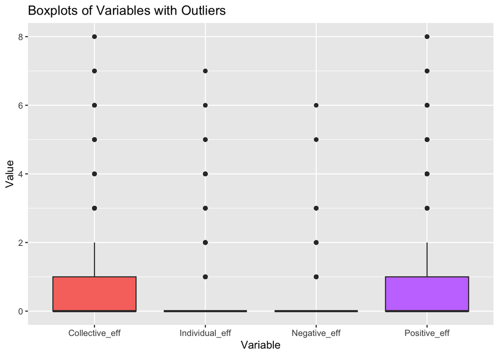

```r
library(ggplot2)

# Combine the four variables into one long format
p2_long <- tidyr::gather(p2, key = "Variable", value = "Value", Positive_eff, Negative_eff, Individual_eff, Collective_eff)

# Create a grouped boxplot with all four variables
ggplot(p2_long, aes(x = Variable, y = Value, fill = Variable)) +
  geom_boxplot() +
  ylab("Value") +
  ggtitle("Boxplots of Variables with Outliers") +
  theme(legend.position = "none")
```

```r
table(p2$Positive_eff)
```

```
##
##    0    1    2    3    4    5    6    7    8
## 5875 2563  949  289  124   35   20    7    5
```

```r
table(p2$Negative_eff)
```

```
##
##    0    1    2    3    5    6
## 9728   99   27   10    2    1
```

```r
table(p2$Individual_eff)
```

```
##
##    0    1    2    3    4    5    6    7
## 8523 1078  171   35   49    7    2    2
```

```r
table(p2$ Collective_eff)
```

```
##
##    0    1    2    3    4    5    6    7    8
## 6635 2315  622  186   64   24   13    5    3
```

```r
#cor(p2$Poverty_percent, p2$Prosperity_ranking)
#cor(p2$White_percent, p2$Minority_percent)
#cor(p2$Pre_Action, p2$Uncertainty_Reduction)
#cor(p2$Social_Disparities, p2$Risk_Factor)
```

```r
# Calculate the variation and mean of X
variance_Positive_eff <- var(p2$Positive_eff,  na.rm = TRUE)
mean_Positive_eff <- mean(p2$Positive_eff,  na.rm = TRUE)
print(variance_Positive_eff)
```

```
## [1] 0.9422385
```

```r
print(mean_Positive_eff)
```

```
## [1] 0.6291679
```

```r
# Calculate the variation and mean of X
variance_Negative_eff <- var(p2$Negative_eff,  na.rm = TRUE)
mean_Negative_eff <- mean(p2$Negative_eff,  na.rm = TRUE)
print(variance_Negative_eff)
```

```
## [1] 0.03841339
```

```r
print(mean_Negative_eff)
```

```
## [1] 0.02016824
```

```r
# Calculate the variation and mean of X
variance_Collective_eff <- var(p2$Collective_eff, na.rm = TRUE)
mean_Collective_eff <- mean(p2$Collective_eff,  na.rm = TRUE)
print(variance_Collective_eff )
```

```
## [1] 0.6926226
```

```r
print(mean_Collective_eff )
```

```
## [1] 0.4692409
```

```r
# Calculate the variation and mean of X
variance_Individual_eff <- var(p2$Individual_eff,  na.rm = TRUE)
mean_Individual_eff <- mean(p2$Individual_eff,  na.rm = TRUE)
print(variance_Individual_eff )
```

```
## [1] 0.292334
```

```r
print(mean_Individual_eff )
```

```
## [1] 0.180602
```

#RQ2a: To what extent risk communication effect health efficacy?

```r
# Convert selected columns to numeric
p2[, c("Social_Disparities", "Risk_Factor", "Uncertainty_Reduction", "Debunk_MI")] <-
  sapply(p2[, c("Social_Disparities", "Risk_Factor", "Uncertainty_Reduction", "Debunk_MI")], as.numeric)

# Calculate the correlation
correlation_matrix <- cor(p2[, c("Social_Disparities", "Risk_Factor", "Uncertainty_Reduction", "Debunk_MI")])

# Print the correlation matrix
print(correlation_matrix)
```

```
##                       Social_Disparities  Risk_Factor Uncertainty_Reduction
## Social_Disparities           1.000000000 -0.004366384           0.005442919
## Risk_Factor                 -0.004366384  1.000000000          -0.005422755
## Uncertainty_Reduction        0.005442919 -0.005422755           1.000000000
## Debunk_MI                    0.019547705  0.029934765           0.004767293
##                         Debunk_MI
## Social_Disparities    0.019547705
## Risk_Factor           0.029934765
## Uncertainty_Reduction 0.004767293
## Debunk_MI             1.000000000
```

```r
glimpse(p2)
```

```
## Rows: 9,867
## Columns: 32
## $ Post_oldid            <chr> "1", "2", "3", "4", "5", "6", "7", "8", "9", "10…
## $ Real_ID               <dbl> 2069, 2070, 2071, 2072, 2073, 2074, 403, 5425, 5…
## $ date                  <chr> "9/22/20", "8/27/20", "12/29/20", "9/29/20", "10…
## $ COVID_Post            <dbl> 1, 1, 1, 1, 1, 1, 1, 1, 1, 1, 1, 1, 1, 1, 1, 1, …
## $ Risk_Factor           <dbl> 1, 1, 1, 1, 1, 1, 1, 1, 1, 1, 1, 1, 1, 1, 1, 2, …
## $ Social_Disparities    <dbl> 1, 1, 1, 1, 1, 1, 1, 1, 1, 1, 1, 1, 1, 1, 1, 1, …
## $ Debunk_MI             <dbl> 1, 1, 1, 1, 1, 1, 1, 1, 1, 1, 1, 1, 1, 1, 1, 1, …
## $ Uncertainty_Reduction <dbl> 2, 2, 2, 2, 2, 2, 1, 2, 2, 2, 2, 2, 1, 2, 2, 1, …
## $ Testing               <dbl> 88, 88, 88, 88, 88, 88, 88, 88, 1, 88, 88, 88, 8…
## $ Vaccine               <dbl> 88, 88, 88, 88, 88, 88, 88, 88, 88, 88, 88, 88, …
## $ Mental_8_YesNo        <dbl> 0, 0, 0, 0, 0, 0, 0, 0, 0, 0, 0, 0, 0, 0, 0, 0, …
## $ Emotion_9_Number      <dbl> 0, 0, 0, 0, 0, 0, 0, 0, 0, 0, 0, 0, 0, 0, 0, 0, …
## $ Praise_10_Number      <dbl> 0, 0, 0, 0, 0, 0, 0, 0, 0, 0, 0, 0, 0, 0, 0, 1, …
```

[output cut: 19 more lines]

```r
table(p2$Social_Disparities)
```

```
##
##    1    2
## 9691  176
```

```r
table(p2$Risk_Factor)
```

```
##
##    1    2
## 8524 1343
```

```r
table(p2$Debunk_MI)
```

```
##
##    1    2
## 9432  435
```

```r
table(p2$Uncertainty_Reduction)
```

```
##
##    1    2
##  478 9389
```

# Positive eff

```r
#transform variable
p2 <- na.omit(p2)
M2a <- zeroinfl(Positive_eff ~ Social_Disparities +
                            Risk_Factor +
                            Uncertainty_Reduction +
                            Debunk_MI,
                 dist = 'poisson',
                 data = p2)
summary(M2a)
```

```
##
## Call:
## zeroinfl(formula = Positive_eff ~ Social_Disparities + Risk_Factor +
##     Uncertainty_Reduction + Debunk_MI, data = p2, dist = "poisson")
##
## Pearson residuals:
##     Min      1Q  Median      3Q     Max
## -1.1257 -0.6617 -0.6617  0.4727  8.4132
##
## Count model coefficients (poisson with log link):
##                       Estimate Std. Error z value Pr(>|z|)
## (Intercept)           -0.80391    0.21225  -3.788 0.000152 ***
## Social_Disparities     0.28963    0.11390   2.543 0.010994 *
## Risk_Factor            0.23296    0.04846   4.807 1.53e-06 ***
## Uncertainty_Reduction  0.04625    0.09455   0.489 0.624712
## Debunk_MI              0.10062    0.09993   1.007 0.313959
##
## Zero-inflation model coefficients (binomial with logit link):
##                       Estimate Std. Error z value Pr(>|z|)
## (Intercept)            -1.6440     0.8742  -1.881 0.060032 .
## Social_Disparities     -0.6728     0.4322  -1.557 0.119554
## Risk_Factor            -0.5320     0.1523  -3.493 0.000478 ***
## Uncertainty_Reduction   0.9503     0.4476   2.123 0.033763 *
## Debunk_MI               0.3854     0.2188   1.761 0.078168 .
## ---
## Signif. codes:  0 '***' 0.001 '**' 0.01 '*' 0.05 '.' 0.1 ' ' 1
##
## Number of iterations in BFGS optimization: 22
## Log-likelihood: -1.031e+04 on 10 Df
```

```r
#transform variable
p2 <- na.omit(p2)
M2a_1 <- zeroinfl(Positive_eff ~ Social_Disparities +
                            Risk_Factor +
                            Uncertainty_Reduction +
                            Debunk_MI,
                 dist = 'negbin',
                 data = p2)
summary(M2a_1)
```

```
##
## Call:
## zeroinfl(formula = Positive_eff ~ Social_Disparities + Risk_Factor +
##     Uncertainty_Reduction + Debunk_MI, data = p2, dist = "negbin")
##
## Pearson residuals:
##     Min      1Q  Median      3Q     Max
## -0.8836 -0.6367 -0.6367  0.4552  8.0983
##
## Count model coefficients (negbin with log link):
##                        Estimate Std. Error z value Pr(>|z|)
## (Intercept)           -0.898434   0.199092  -4.513 6.40e-06 ***
## Social_Disparities     0.381738   0.103820   3.677 0.000236 ***
## Risk_Factor            0.286866   0.052864   5.427 5.75e-08 ***
## Uncertainty_Reduction -0.102982   0.073881  -1.394 0.163354
## Debunk_MI              0.005832   0.102824   0.057 0.954766
## Log(theta)             0.561544   0.100306   5.598 2.16e-08 ***
##
## Zero-inflation model coefficients (binomial with logit link):
##                        Estimate Std. Error z value Pr(>|z|)
## (Intercept)             -3.7618  1188.9135  -0.003    0.997
## Social_Disparities     -11.3203   332.0833  -0.034    0.973
## Risk_Factor            -14.0839   771.5471  -0.018    0.985
## Uncertainty_Reduction   13.2604   420.6976   0.032    0.975
## Debunk_MI                0.4875     0.6629   0.735    0.462
## ---
## Signif. codes:  0 '***' 0.001 '**' 0.01 '*' 0.05 '.' 0.1 ' ' 1
##
## Theta = 1.7534
## Number of iterations in BFGS optimization: 47
## Log-likelihood: -1.023e+04 on 11 Df
```

```r
missing_columns <- colnames(p2)[apply(is.na(p2), 2, any)]
missing_columns
```

```
## character(0)
```

```r
# Run the Vuong test to compare the models
vuong_testa <- vuong(M2a, M2a_1)
```

```
## Vuong Non-Nested Hypothesis Test-Statistic:
## (test-statistic is asymptotically distributed N(0,1) under the
##  null that the models are indistinguishible)
## -------------------------------------------------------------
##               Vuong z-statistic             H_A    p-value
## Raw                   -5.689025 model2 > model1 6.3883e-09
## AIC-corrected         -5.689025 model2 > model1 6.3883e-09
## BIC-corrected         -5.689025 model2 > model1 6.3883e-09
```

```r
# View the results of the Vuong test
summary(vuong_testa)
```

```
## Length  Class   Mode
##      0   NULL   NULL
```

#The results of the Vuong test you provided indicate a highly significant preference for “model2” over “model1.” Here’s the interpretation of the results:

#Interpretation: The p-value is extremely small (close to zero), indicating strong statistical evidence that “model2” is significantly better than “model1” in terms of its fit to the data. This suggests a clear preference for “model2” based on the test results.

#In summary, the very low p-value and negative z-statistics provide robust evidence that “model2” outperforms “model1” in explaining the data. This is a highly significant result in favor of “model2.”

==> negbin use

```r
model_parameters(M2a_1)
```

```
## # Fixed Effects
##
## Parameter             | Log-Mean |   SE |         95% CI |     z |      p
## -------------------------------------------------------------------------
## (Intercept)           |    -0.90 | 0.20 | [-1.29, -0.51] | -4.51 | < .001
## Social Disparities    |     0.38 | 0.10 | [ 0.18,  0.59] |  3.68 | < .001
## Risk Factor           |     0.29 | 0.05 | [ 0.18,  0.39] |  5.43 | < .001
## Uncertainty Reduction |    -0.10 | 0.07 | [-0.25,  0.04] | -1.39 | 0.163
## Debunk MI             | 5.83e-03 | 0.10 | [-0.20,  0.21] |  0.06 | 0.955
##
## # Zero-Inflation
##
## Parameter             | Log-Odds |      SE |              95% CI |         z |     p
## ------------------------------------------------------------------------------------
## (Intercept)           |    -3.76 | 1188.91 | [-2333.99, 2326.47] | -3.16e-03 | 0.997
## Social Disparities    |   -11.32 |  332.08 | [ -662.19,  639.55] |     -0.03 | 0.973
## Risk Factor           |   -14.08 |  771.55 | [-1526.29, 1498.12] |     -0.02 | 0.985
## Uncertainty Reduction |    13.26 |  420.70 | [ -811.29,  837.81] |      0.03 | 0.975
## Debunk MI             |     0.49 |    0.66 | [   -0.81,    1.79] |      0.74 | 0.462
```

```
##
## The model has a log- or logit-link. Consider using `exponentiate =
##   TRUE` to interpret coefficients as ratios.
```

```r
# Define the APA-style theme
theme_apa <- function() {
  theme_minimal() +
    theme(
      text = element_text(family = "Times New Roman", size = 10),
      plot.title = element_text(size = 14, face = "bold", hjust = 0.5),
      axis.title = element_text(size = 12, face = "bold"),
      axis.text = element_text(size = 10),
      panel.grid.major = element_blank(),
      panel.grid.minor = element_blank(),
      panel.border = element_blank(),
      panel.background = element_blank(),
      legend.position = "right",
      legend.text = element_text(size = 12),
      axis.line = element_line(color = "black")
    )
}
```

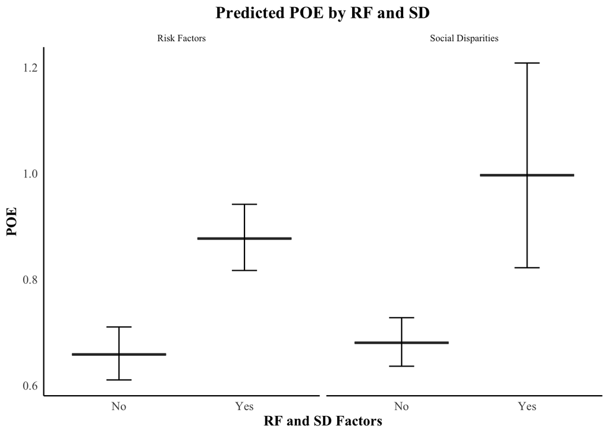

```r
# Load required libraries
library(ggplot2)
library(ggeffects)

# Create ggeffects objects for Risk_Factor and Social_Disparities
ge_risk <- ggpredict(M2a_1, terms = "Risk_Factor")
ge_social <- ggpredict(M2a_1, terms = "Social_Disparities")

# Create data frames for both boxplots
boxplot_data_risk <- data.frame(
  Group = "Risk Factors",  # Add a Group column to identify the data source
  Risk_Factor = c(0, 1),
  Predicted = ge_risk$predicted,
  CI_lower = ge_risk$conf.low,
  CI_upper = ge_risk$conf.high
)

boxplot_data_social <- data.frame(
  Group = "Social Disparities",  # Add a Group column to identify the data source
  Risk_Factor = c(0, 1),
  Predicted = ge_social$predicted,
  CI_lower = ge_social$conf.low,
  CI_upper = ge_social$conf.high
)

# Combine the data frames
combined_data <- rbind(boxplot_data_risk, boxplot_data_social)

# Create a boxplot with facets
ggplot(combined_data, aes(x = as.factor(Risk_Factor), y = Predicted)) +
  geom_boxplot() +
  geom_errorbar(aes(ymin = CI_lower, ymax = CI_upper), width = 0.2, position = position_dodge(0.75)) +
  labs(title = "Predicted POE by RF and SD",
       x = "RF and SD Factors",
       y = "POE") +
  scale_x_discrete(labels = c("No", "Yes")) +
  facet_grid(. ~ Group) +  # Facet by Group (Risk Factor and Social Disparities)
  theme_apa()
```

```r
# Save the combined boxplot as a PNG file
ggsave("risk_POE.png", plot = last_plot(), width = 8, height = 4, units = "in")
```

#Negative eff

```r
p2 <- na.omit(p2)
M2b <- zeroinfl(Negative_eff ~ Social_Disparities +
                            Risk_Factor +
                            Uncertainty_Reduction +
                            Debunk_MI,
                 dist = 'poisson',
                 data = p2)
summary(M2b)
```

```
##
## Call:
## zeroinfl(formula = Negative_eff ~ Social_Disparities + Risk_Factor +
##     Uncertainty_Reduction + Debunk_MI, data = p2, dist = "poisson")
##
## Pearson residuals:
##      Min       1Q   Median       3Q      Max
## -0.20878 -0.08037 -0.08037 -0.08037 40.57369
##
## Count model coefficients (poisson with log link):
##                       Estimate Std. Error z value Pr(>|z|)
## (Intercept)            8.40856    1.30481   6.444 1.16e-10 ***
## Social_Disparities    -4.16992    0.80956  -5.151 2.59e-07 ***
## Risk_Factor           -0.06694    0.24045  -0.278    0.781
## Uncertainty_Reduction -0.45736    0.44811  -1.021    0.307
## Debunk_MI             -3.42152    0.35069  -9.757  < 2e-16 ***
##
## Zero-inflation model coefficients (binomial with logit link):
##                       Estimate Std. Error z value Pr(>|z|)
## (Intercept)            25.8030    55.9132   0.461    0.644
## Social_Disparities     -8.6204    30.0811  -0.287    0.774
## Risk_Factor            -1.9524     0.2497  -7.818 5.38e-15 ***
## Uncertainty_Reduction  -0.4045     0.5256  -0.770    0.442
## Debunk_MI             -10.1653    47.1603  -0.216    0.829
## ---
## Signif. codes:  0 '***' 0.001 '**' 0.01 '*' 0.05 '.' 0.1 ' ' 1
##
## Number of iterations in BFGS optimization: 64
## Log-likelihood: -771.4 on 10 Df
```

```r
p2 <- na.omit(p2)
M2b_1 <- zeroinfl(Negative_eff ~ Social_Disparities +
                            Risk_Factor +
                            Uncertainty_Reduction +
                            Debunk_MI,
                 dist = 'negbin',
                 data = p2)
summary(M2b_1)
```

```
##
## Call:
## zeroinfl(formula = Negative_eff ~ Social_Disparities + Risk_Factor +
##     Uncertainty_Reduction + Debunk_MI, data = p2, dist = "negbin")
##
## Pearson residuals:
##      Min       1Q   Median       3Q      Max
## -0.21397 -0.07657 -0.07657 -0.07657 38.38505
##
## Count model coefficients (negbin with log link):
##                       Estimate Std. Error z value Pr(>|z|)
## (Intercept)             5.5566     3.0453   1.825  0.06806 .
## Social_Disparities     -3.0863     1.0911  -2.829  0.00467 **
## Risk_Factor            -0.1075     0.3283  -0.328  0.74319
## Uncertainty_Reduction  -0.6552     0.6928  -0.946  0.34428
## Debunk_MI              -2.3281     0.8693  -2.678  0.00740 **
## Log(theta)             -1.0146     1.1719  -0.866  0.38660
##
## Zero-inflation model coefficients (binomial with logit link):
##                       Estimate Std. Error z value Pr(>|z|)
## (Intercept)            31.6116   339.9860   0.093    0.926
## Social_Disparities    -11.4465   238.5788  -0.048    0.962
## Risk_Factor            -2.1866     0.4481  -4.880 1.06e-06 ***
## Uncertainty_Reduction  -0.5771     0.6858  -0.841    0.400
## Debunk_MI             -13.7166   242.2386  -0.057    0.955
## ---
## Signif. codes:  0 '***' 0.001 '**' 0.01 '*' 0.05 '.' 0.1 ' ' 1
##
## Theta = 0.3625
## Number of iterations in BFGS optimization: 78
## Log-likelihood: -767.4 on 11 Df
```

```r
# Run the Vuong test to compare the models
vuong_testb <- vuong(M2b, M2b_1)
```

```
## Vuong Non-Nested Hypothesis Test-Statistic:
## (test-statistic is asymptotically distributed N(0,1) under the
##  null that the models are indistinguishible)
## -------------------------------------------------------------
##               Vuong z-statistic             H_A p-value
## Raw                   -1.125515 model2 > model1 0.13019
## AIC-corrected         -1.125515 model2 > model1 0.13019
## BIC-corrected         -1.125515 model2 > model1 0.13019
```

```r
# View the results of the Vuong test
summary(vuong_testb)
```

```
## Length  Class   Mode
##      0   NULL   NULL
```

#The Vuong test results you provided indicate a preference for “model2” over “model1” but with a less significant p-value. Here’s the interpretation of the results:

#In summary, the results suggest that there may be a preference for “model2,” but the evidence is not very strong based on the p-value. The interpretation of the Vuong test results should take into consideration the specific context of your analysis and your chosen significance level.

==> poisson

```r
model_parameters(M2b)
```

```
## # Fixed Effects
##
## Parameter             | Log-Mean |   SE |         95% CI |     z |      p
## -------------------------------------------------------------------------
## (Intercept)           |     8.41 | 1.30 | [ 5.85, 10.97] |  6.44 | < .001
## Social Disparities    |    -4.17 | 0.81 | [-5.76, -2.58] | -5.15 | < .001
## Risk Factor           |    -0.07 | 0.24 | [-0.54,  0.40] | -0.28 | 0.781
## Uncertainty Reduction |    -0.46 | 0.45 | [-1.34,  0.42] | -1.02 | 0.307
## Debunk MI             |    -3.42 | 0.35 | [-4.11, -2.73] | -9.76 | < .001
##
## # Zero-Inflation
##
## Parameter             | Log-Odds |    SE |            95% CI |     z |      p
## -----------------------------------------------------------------------------
## (Intercept)           |    25.80 | 55.91 | [ -83.78, 135.39] |  0.46 | 0.644
## Social Disparities    |    -8.62 | 30.08 | [ -67.58,  50.34] | -0.29 | 0.774
## Risk Factor           |    -1.95 |  0.25 | [  -2.44,  -1.46] | -7.82 | < .001
## Uncertainty Reduction |    -0.40 |  0.53 | [  -1.43,   0.63] | -0.77 | 0.442
## Debunk MI             |   -10.17 | 47.16 | [-102.60,  82.27] | -0.22 | 0.829
```

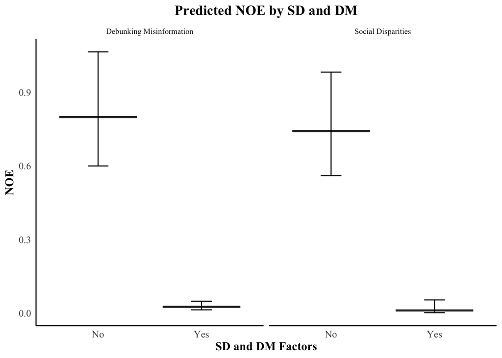

```r
# Create ggeffects objects for Risk_Factor and Social_Disparities
ge_social <- ggpredict(M2b, terms = "Social_Disparities")
ge_debunk <- ggpredict(M2b, terms = "Debunk_MI")

# Create data frames for both boxplots
boxplot_data_social <- data.frame(
  Group = "Social Disparities",  # Add a Group column to identify the data source
  Social_Disparities = c(0, 1),
  Predicted = ge_social$predicted,
  CI_lower = ge_social$conf.low,
  CI_upper = ge_social$conf.high
)

boxplot_data_debunk <- data.frame(
  Group = "Debunking Misinformation",  # Add a Group column to identify the data source
  Social_Disparities = c(0, 1),  # Ensure that the column name matches the previous data frame
  Predicted = ge_debunk$predicted,
  CI_lower = ge_debunk$conf.low,
  CI_upper = ge_debunk$conf.high
)


# Combine the data frames
combined_data1 <- rbind(boxplot_data_debunk, boxplot_data_social)

# Create a boxplot with facets
ggplot(combined_data1, aes(x = as.factor(Social_Disparities), y = Predicted)) +
  geom_boxplot() +
  geom_errorbar(aes(ymin = CI_lower, ymax = CI_upper), width = 0.2, position = position_dodge(0.75)) +
  labs(title = "Predicted NOE by SD and DM",
       x = "SD and DM Factors",
       y = "NOE") +
  scale_x_discrete(labels = c("No", "Yes")) +
  facet_grid(. ~ Group) +  # Facet by Group (Risk Factor and Social Disparities)
  theme_apa()
```

```r
# Save the combined boxplot as a PNG file
ggsave("risk_NOE.png", plot = last_plot(), width = 8, height = 4, units = "in")
```

#Collective eff

```r
p2 <- na.omit(p2)
M2c <- zeroinfl(Collective_eff ~ Social_Disparities +
                            Risk_Factor +
                            Uncertainty_Reduction +
                            Debunk_MI,
                 dist = 'poisson',
                 data = p2)
summary(M2c)
```

```
##
## Call:
## zeroinfl(formula = Collective_eff ~ Social_Disparities + Risk_Factor +
##     Uncertainty_Reduction + Debunk_MI, data = p2, dist = "poisson")
##
## Pearson residuals:
##     Min      1Q  Median      3Q     Max
## -1.1058 -0.5758 -0.5758  0.7770 10.2463
##
## Count model coefficients (poisson with log link):
##                       Estimate Std. Error z value Pr(>|z|)
## (Intercept)            -1.1153     0.2853  -3.909 9.28e-05 ***
## Social_Disparities      0.3917     0.1280   3.059  0.00222 **
## Risk_Factor             0.3912     0.0584   6.698 2.11e-11 ***
## Uncertainty_Reduction   0.1155     0.1341   0.861  0.38910
## Debunk_MI              -0.2419     0.1543  -1.568  0.11696
##
## Zero-inflation model coefficients (binomial with logit link):
##                        Estimate Std. Error z value Pr(>|z|)
## (Intercept)           -0.885240   1.180292  -0.750   0.4532
## Social_Disparities    -1.159505   0.631576  -1.836   0.0664 .
## Risk_Factor           -0.347203   0.155528  -2.232   0.0256 *
## Uncertainty_Reduction  0.990125   0.619267   1.599   0.1099
## Debunk_MI              0.006351   0.384125   0.017   0.9868
## ---
## Signif. codes:  0 '***' 0.001 '**' 0.01 '*' 0.05 '.' 0.1 ' ' 1
##
## Number of iterations in BFGS optimization: 48
## Log-likelihood: -8724 on 10 Df
```

```r
p2 <- na.omit(p2)
M2c_1 <- zeroinfl(Collective_eff ~ Social_Disparities +
                            Risk_Factor +
                            Uncertainty_Reduction +
                            Debunk_MI, dist = 'geometric',
                 data = p2)
summary(M2c_1)
```

```
##
## Call:
## zeroinfl(formula = Collective_eff ~ Social_Disparities + Risk_Factor +
##     Uncertainty_Reduction + Debunk_MI, data = p2, dist = "geometric")
##
## Pearson residuals:
##     Min      1Q  Median      3Q     Max
## -0.7915 -0.5467 -0.5467  0.7356  9.7117
##
## Count model coefficients (geometric with log link):
##                       Estimate Std. Error z value Pr(>|z|)
## (Intercept)            -1.4470     0.2237  -6.469 9.88e-11 ***
## Social_Disparities      0.6897     0.1155   5.972 2.34e-09 ***
## Risk_Factor             0.5097     0.0475  10.730  < 2e-16 ***
## Uncertainty_Reduction  -0.1701     0.0822  -2.070  0.03849 *
## Debunk_MI              -0.2646     0.0969  -2.731  0.00631 **
##
## Zero-inflation model coefficients (binomial with logit link):
##                        Estimate Std. Error z value Pr(>|z|)
## (Intercept)              -9.553  21921.714   0.000    1.000
## Social_Disparities       -4.667  15438.533   0.000    1.000
## Risk_Factor              -5.054  10432.219   0.000    1.000
## Uncertainty_Reduction     2.358   3551.763   0.001    0.999
## Debunk_MI                -3.037   9408.532   0.000    1.000
## ---
## Signif. codes:  0 '***' 0.001 '**' 0.01 '*' 0.05 '.' 0.1 ' ' 1
##
## Number of iterations in BFGS optimization: 41
## Log-likelihood: -8650 on 10 Df
```

```r
cor(p2[, c("Social_Disparities", "Risk_Factor", "Uncertainty_Reduction", "Debunk_MI")])
```

```
##                       Social_Disparities  Risk_Factor Uncertainty_Reduction
## Social_Disparities           1.000000000 -0.001107591           0.002671436
## Risk_Factor                 -0.001107591  1.000000000          -0.003646663
## Uncertainty_Reduction        0.002671436 -0.003646663           1.000000000
## Debunk_MI                    0.020200884  0.035376604           0.002657225
##                         Debunk_MI
## Social_Disparities    0.020200884
## Risk_Factor           0.035376604
## Uncertainty_Reduction 0.002657225
## Debunk_MI             1.000000000
```

```r
# Run the Vuong test to compare the models
vuong_testc <- vuong(M2c, M2c_1)
```

```
## Vuong Non-Nested Hypothesis Test-Statistic:
## (test-statistic is asymptotically distributed N(0,1) under the
##  null that the models are indistinguishible)
## -------------------------------------------------------------
##               Vuong z-statistic             H_A   p-value
## Raw                   -4.353959 model2 > model1 6.685e-06
## AIC-corrected         -4.353959 model2 > model1 6.685e-06
## BIC-corrected         -4.353959 model2 > model1 6.685e-06
```

```r
# View the results of the Vuong test
summary(vuong_testc)
```

```
## Length  Class   Mode
##      0   NULL   NULL
```

==> geometric

```r
model_parameters(M2c_1)
```

```
## # Fixed Effects
##
## Parameter             | Log-Mean |   SE |         95% CI |     z |      p
## -------------------------------------------------------------------------
## (Intercept)           |    -1.45 | 0.22 | [-1.89, -1.01] | -6.47 | < .001
## Social Disparities    |     0.69 | 0.12 | [ 0.46,  0.92] |  5.97 | < .001
## Risk Factor           |     0.51 | 0.05 | [ 0.42,  0.60] | 10.73 | < .001
## Uncertainty Reduction |    -0.17 | 0.08 | [-0.33, -0.01] | -2.07 | 0.038
## Debunk MI             |    -0.26 | 0.10 | [-0.45, -0.07] | -2.73 | 0.006
##
## # Zero-Inflation
##
## Parameter             | Log-Odds |       SE |                95% CI |         z |      p
## ----------------------------------------------------------------------------------------
## (Intercept)           |    -9.55 | 21921.71 | [-42975.32, 42956.22] | -4.36e-04 | > .999
## Social Disparities    |    -4.67 | 15438.53 | [-30263.64, 30254.30] | -3.02e-04 | > .999
## Risk Factor           |    -5.05 | 10432.22 | [-20451.83, 20441.72] | -4.84e-04 | > .999
## Uncertainty Reduction |     2.36 |  3551.76 | [ -6958.97,  6963.69] |  6.64e-04 | > .999
## Debunk MI             |    -3.04 |  9408.53 | [-18443.42, 18437.35] | -3.23e-04 | > .999
```

```r
library(ggeffects)
library(patchwork)
```

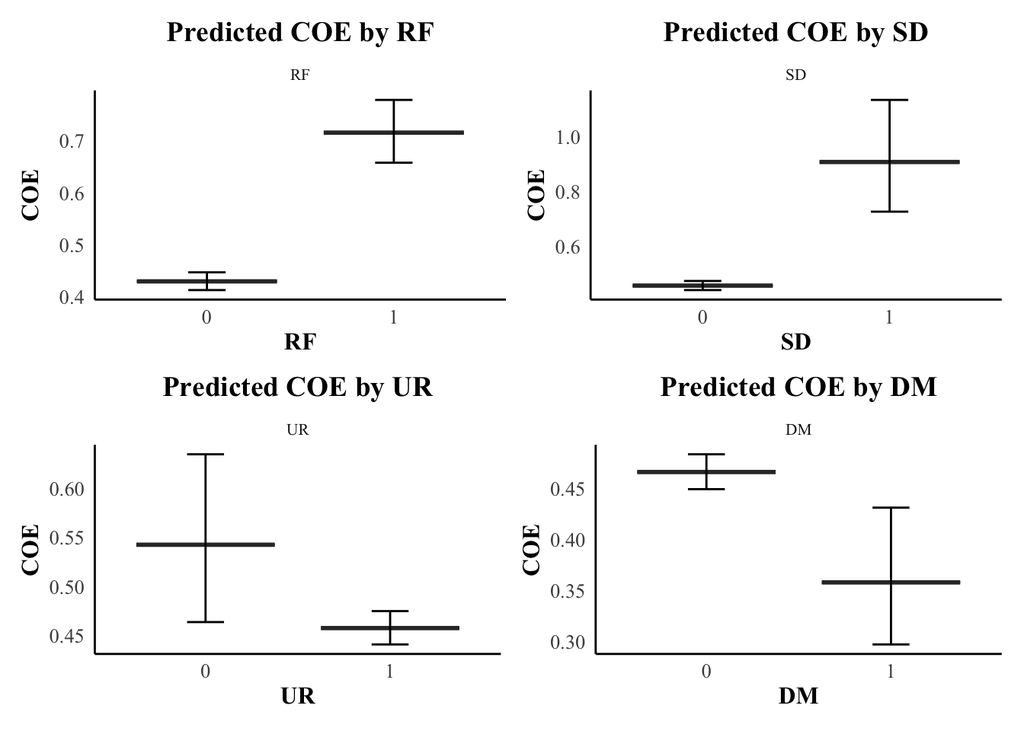

```r
library(ggplot2)

# Create ggeffects objects for Risk_Factor and Social_Disparities
ge_risk <- ggpredict(M2c_1, terms = "Risk_Factor")
ge_social <- ggpredict(M2c_1, terms = "Social_Disparities")
ge_uncertain <- ggpredict(M2c_1, terms = "Uncertainty_Reduction")
ge_debunk <- ggpredict(M2c_1, terms = "Debunk_MI")

boxplot_data_social <- data.frame(
  Group = "SD",  # Add a Group column to identify the data source
  Risk_Factor = c(0, 1),
  Predicted = ge_social$predicted,
  CI_lower = ge_social$conf.low,
  CI_upper = ge_social$conf.high
)

# Create data frames for both boxplots
boxplot_data_risk <- data.frame(
  Group = "RF",  # Add a Group column to identify the data source
  Risk_Factor = c(0, 1),
  Predicted = ge_risk$predicted,
  CI_lower = ge_risk$conf.low,
  CI_upper = ge_risk$conf.high
)

boxplot_data_uncertain <- data.frame(
  Group = "UR",  # Add a Group column to identify the data source
  Risk_Factor = c(0, 1),
  Predicted = ge_uncertain$predicted,
  CI_lower = ge_uncertain$conf.low,
  CI_upper = ge_uncertain$conf.high
)

# Create data frames for both boxplots
boxplot_data_debunk <- data.frame(
  Group = "DM",  # Add a Group column to identify the data source
  Risk_Factor = c(0, 1),
  Predicted = ge_debunk$predicted,
  CI_lower = ge_debunk$conf.low,
  CI_upper = ge_debunk$conf.high
)

# Combine the data frames
combined_data <- rbind(boxplot_data_risk, boxplot_data_social,
                       boxplot_data_uncertain, boxplot_data_debunk)

# Create the individual plots
plot1 <- ggplot(combined_data[combined_data$Group == "RF", ], aes(x = as.factor(Risk_Factor), y = Predicted)) +
  geom_boxplot() +
  geom_errorbar(aes(ymin = CI_lower, ymax = CI_upper), width = 0.2, position = position_dodge(0.75)) +
  labs(title = "Predicted COE by RF",
       x = "RF",
       y = "COE") +
  scale_x_discrete(labels = c("0", "1")) +  # Set x-axis labels to "0" and "1"
  facet_grid(. ~ Group) +
  theme_apa()

plot2 <- ggplot(combined_data[combined_data$Group == "SD", ], aes(x = as.factor(Risk_Factor), y = Predicted)) +
  geom_boxplot() +
  geom_errorbar(aes(ymin = CI_lower, ymax = CI_upper), width = 0.2, position = position_dodge(0.75)) +
  labs(title = "Predicted COE by SD",
       x = "SD",
       y = "COE") +
  scale_x_discrete(labels = c("0", "1")) +  # Set x-axis labels to "0" and "1"
  facet_grid(. ~ Group) +
  theme_apa()

plot3 <- ggplot(combined_data[combined_data$Group == "UR", ], aes(x = as.factor(Risk_Factor), y = Predicted)) +
  geom_boxplot() +
  geom_errorbar(aes(ymin = CI_lower, ymax = CI_upper), width = 0.2, position = position_dodge(0.75)) +
  labs(title = "Predicted COE by UR",
       x = "UR",
       y = "COE") +
  scale_x_discrete(labels = c("0", "1")) +  # Set x-axis labels to "0" and "1"
  facet_grid(. ~ Group) +
  theme_apa()

plot4 <- ggplot(combined_data[combined_data$Group == "DM", ], aes(x = as.factor(Risk_Factor), y = Predicted)) +
  geom_boxplot() +
  geom_errorbar(aes(ymin = CI_lower, ymax = CI_upper), width = 0.2, position = position_dodge(0.75)) +
  labs(title = "Predicted COE by DM",
       x = "DM",
       y = "COE") +
  scale_x_discrete(labels = c("0", "1")) +  # Set x-axis labels to "0" and "1"
  facet_grid(. ~ Group) +
  theme_apa()

# Combine the plots into a 2x2 grid layout
combined_plots <- (plot1 + plot2) / (plot3 + plot4)
combined_plots
```

```r
# Save the combined plots as a PNG file
ggsave("risk_COE.png", plot = combined_plots, width = 8, height = 8, units = "in")
```

#Individual Eff

```r
M2d <- zeroinfl(Individual_eff ~ Social_Disparities +
                            Risk_Factor +
                            Uncertainty_Reduction +
                            Debunk_MI,
                 dist = 'poisson',
                 data = p2)
summary(M2d)
```

```
##
## Call:
## zeroinfl(formula = Individual_eff ~ Social_Disparities + Risk_Factor +
##     Uncertainty_Reduction + Debunk_MI, data = p2, dist = "poisson")
##
## Pearson residuals:
##     Min      1Q  Median      3Q     Max
## -0.5621 -0.3457 -0.3457 -0.3457 13.9251
##
## Count model coefficients (poisson with log link):
##                       Estimate Std. Error z value Pr(>|z|)
## (Intercept)           -2.08058    0.55482  -3.750 0.000177 ***
## Social_Disparities     0.67215    0.33578   2.002 0.045307 *
## Risk_Factor            0.06921    0.11828   0.585 0.558421
## Uncertainty_Reduction  0.29025    0.22624   1.283 0.199515
## Debunk_MI              0.22822    0.17736   1.287 0.198174
##
## Zero-inflation model coefficients (binomial with logit link):
##                       Estimate Std. Error z value Pr(>|z|)
## (Intercept)            -1.8501     0.9175  -2.016 0.043749 *
## Social_Disparities      1.4338     0.3851   3.724 0.000196 ***
## Risk_Factor            -0.2992     0.1684  -1.776 0.075722 .
## Uncertainty_Reduction   0.9409     0.4246   2.216 0.026695 *
## Debunk_MI              -0.2625     0.2579  -1.018 0.308802
## ---
## Signif. codes:  0 '***' 0.001 '**' 0.01 '*' 0.05 '.' 0.1 ' ' 1
##
## Number of iterations in BFGS optimization: 17
## Log-likelihood: -4765 on 10 Df
```

```r
M2d_1 <- zeroinfl(Individual_eff ~ Social_Disparities +
                            Risk_Factor +
                            Uncertainty_Reduction +
                            Debunk_MI,
                 dist = 'geometric',
                 data = p2)
summary(M2d_1)
```

```
##
## Call:
## zeroinfl(formula = Individual_eff ~ Social_Disparities + Risk_Factor +
##     Uncertainty_Reduction + Debunk_MI, data = p2, dist = "geometric")
##
## Pearson residuals:
##     Min      1Q  Median      3Q     Max
## -0.4945 -0.3388 -0.3388 -0.3388 13.6581
##
## Count model coefficients (geometric with log link):
##                       Estimate Std. Error z value Pr(>|z|)
## (Intercept)            -2.5297     0.6010  -4.209 2.56e-05 ***
## Social_Disparities      0.6692     0.5061   1.322    0.186
## Risk_Factor             0.1007     0.1368   0.736    0.462
## Uncertainty_Reduction   0.2072     0.1987   1.043    0.297
## Debunk_MI               0.2147     0.2076   1.034    0.301
##
## Zero-inflation model coefficients (binomial with logit link):
##                       Estimate Std. Error z value Pr(>|z|)
## (Intercept)            -4.4829     2.1594  -2.076 0.037894 *
## Social_Disparities      1.8373     0.5549   3.311 0.000929 ***
## Risk_Factor            -0.4208     0.3192  -1.318 0.187426
## Uncertainty_Reduction   1.7274     1.1306   1.528 0.126549
## Debunk_MI              -0.4876     0.5175  -0.942 0.346002
## ---
## Signif. codes:  0 '***' 0.001 '**' 0.01 '*' 0.05 '.' 0.1 ' ' 1
##
## Number of iterations in BFGS optimization: 32
## Log-likelihood: -4713 on 10 Df
```

```r
# Run the Vuong test to compare the models
vuong_testd <- vuong(M2d, M2d_1)
```

```
## Vuong Non-Nested Hypothesis Test-Statistic:
## (test-statistic is asymptotically distributed N(0,1) under the
##  null that the models are indistinguishible)
## -------------------------------------------------------------
##               Vuong z-statistic             H_A    p-value
## Raw                   -6.734415 model2 > model1 8.2295e-12
## AIC-corrected         -6.734415 model2 > model1 8.2295e-12
## BIC-corrected         -6.734415 model2 > model1 8.2295e-12
```

```r
# View the results of the Vuong test
summary(vuong_testd)
```

```
## Length  Class   Mode
##      0   NULL   NULL
```

#The Vuong z-statistic results you’ve provided suggest strong evidence in favor of “model2” over “model1.” Here’s the interpretation of the results:

#This suggests that “model2” is the preferred model based on the Vuong test, and this preference is highly statistically significant. In practical terms, it #means that “model2” likely provides a better fit or explanation for the data compared to “model1.”

==> geometric

```r
model_parameters(M2d_1)
```

```
## # Fixed Effects
##
## Parameter             | Log-Mean |   SE |         95% CI |     z |      p
## -------------------------------------------------------------------------
## (Intercept)           |    -2.53 | 0.60 | [-3.71, -1.35] | -4.21 | < .001
## Social Disparities    |     0.67 | 0.51 | [-0.32,  1.66] |  1.32 | 0.186
## Risk Factor           |     0.10 | 0.14 | [-0.17,  0.37] |  0.74 | 0.462
## Uncertainty Reduction |     0.21 | 0.20 | [-0.18,  0.60] |  1.04 | 0.297
## Debunk MI             |     0.21 | 0.21 | [-0.19,  0.62] |  1.03 | 0.301
##
## # Zero-Inflation
##
## Parameter             | Log-Odds |   SE |         95% CI |     z |      p
## -------------------------------------------------------------------------
## (Intercept)           |    -4.48 | 2.16 | [-8.72, -0.25] | -2.08 | 0.038
## Social Disparities    |     1.84 | 0.55 | [ 0.75,  2.92] |  3.31 | < .001
## Risk Factor           |    -0.42 | 0.32 | [-1.05,  0.20] | -1.32 | 0.187
## Uncertainty Reduction |     1.73 | 1.13 | [-0.49,  3.94] |  1.53 | 0.127
## Debunk MI             |    -0.49 | 0.52 | [-1.50,  0.53] | -0.94 | 0.346
```

#Type III ANOVA

```r
library(car)
Anova(M2a_1, type = 3)
```

```
## Analysis of Deviance Table (Type III tests)
##
## Response: Positive_eff
##                       Df   Chisq Pr(>Chisq)
## Social_Disparities     1 13.5197  0.0002361 ***
## Risk_Factor            1 29.4471  5.746e-08 ***
## Uncertainty_Reduction  1  1.9429  0.1633536
## Debunk_MI              1  0.0032  0.9547664
## ---
## Signif. codes:  0 '***' 0.001 '**' 0.01 '*' 0.05 '.' 0.1 ' ' 1
```

```r
Anova(M2b, type = 3)
```

```
## Analysis of Deviance Table (Type III tests)
##
## Response: Negative_eff
##                       Df   Chisq Pr(>Chisq)
## Social_Disparities     1 26.5314  2.593e-07 ***
## Risk_Factor            1  0.0775     0.7807
## Uncertainty_Reduction  1  1.0417     0.3074
## Debunk_MI              1 95.1921  < 2.2e-16 ***
## ---
## Signif. codes:  0 '***' 0.001 '**' 0.01 '*' 0.05 '.' 0.1 ' ' 1
```

```r
Anova(M2c_1, type = 3)
```

```
## Analysis of Deviance Table (Type III tests)
##
## Response: Collective_eff
##                       Df    Chisq Pr(>Chisq)
## Social_Disparities     1  35.6668  2.341e-09 ***
## Risk_Factor            1 115.1396  < 2.2e-16 ***
## Uncertainty_Reduction  1   4.2832   0.038491 *
## Debunk_MI              1   7.4586   0.006313 **
## ---
## Signif. codes:  0 '***' 0.001 '**' 0.01 '*' 0.05 '.' 0.1 ' ' 1
```

```r
Anova(M2d_1, type = 3)
```

```
## Analysis of Deviance Table (Type III tests)
##
## Response: Individual_eff
##                       Df  Chisq Pr(>Chisq)
## Social_Disparities     1 1.7483     0.1861
## Risk_Factor            1 0.5419     0.4616
## Uncertainty_Reduction  1 1.0878     0.2970
## Debunk_MI              1 1.0690     0.3012
```

#RQ2b: To what extent socio-economic factors effect health efficacy?

```r
require(pscl)
require(car)
require(MASS)
require(boot)
library(lattice) # alternatively can use package ZIM for zero-inflated models
library(lmtest)
library(tidyverse)
library(cowplot)
```

```r
p4 <- p2 %>%
  mutate(Trifecta = as.factor(Trifecta))
p4
```

```
## # A tibble: 9,445 × 32
##    Post_oldid Real_ID date   COVID_Post Risk_Factor Social_Disparities Debunk_MI
##    <chr>        <dbl> <chr>       <dbl>       <dbl>              <dbl>     <dbl>
##  1 1             2069 9/22/…          1           1                  1         1
##  2 2             2070 8/27/…          1           1                  1         1
##  3 3             2071 12/29…          1           1                  1         1
##  4 4             2072 9/29/…          1           1                  1         1
##  5 5             2073 10/6/…          1           1                  1         1
##  6 6             2074 12/31…          1           1                  1         1
##  7 7              403 4/2/20          1           1                  1         1
##  8 8             5425 12/1/…          1           1                  1         1
##  9 9             5842 12/20…          1           1                  1         1
## 10 10            2075 3/5/20          1           1                  1         1
## # ℹ 9,435 more rows
## # ℹ 25 more variables: Uncertainty_Reduction <dbl>, Testing <dbl>,
## #   Vaccine <dbl>, Mental_8_YesNo <dbl>, Emotion_9_Number <dbl>,
## #   Praise_10_Number <dbl>, Pop_11_Number <dbl>, Language_12_Number <dbl>,
## #   Pre_Action <dbl>, Positive_eff <dbl>, Negative_eff <dbl>,
## #   Individual_eff <dbl>, Collective_eff <dbl>, State_recode <dbl>,
## #   Gov_poli <dbl>, Trifecta <fct>, White_percent <dbl>, …
```

#Positive_eff

```r
p4 <- na.omit(p4)
M2b1 <- zeroinfl(Positive_eff ~ Trifecta +
                            Minority_percent +
                            Poverty_percent,
                 dist = "poisson",
                 data = p4)
summary(M2b1)
```

```
##
## Call:
## zeroinfl(formula = Positive_eff ~ Trifecta + Minority_percent + Poverty_percent,
##     data = p4, dist = "poisson")
##
## Pearson residuals:
##     Min      1Q  Median      3Q     Max
## -0.9681 -0.6937 -0.6145  0.4873 11.3385
##
## Count model coefficients (poisson with log link):
##                   Estimate Std. Error z value Pr(>|z|)
## (Intercept)       0.456690   0.129085   3.538 0.000403 ***
## Trifecta2        -0.202374   0.048029  -4.214 2.51e-05 ***
## Trifecta3         0.274692   0.056088   4.897 9.71e-07 ***
## Minority_percent  0.003985   0.001597   2.495 0.012582 *
## Poverty_percent  -0.048626   0.011211  -4.337 1.44e-05 ***
##
## Zero-inflation model coefficients (binomial with logit link):
##                   Estimate Std. Error z value Pr(>|z|)
## (Intercept)       0.349447   0.330321   1.058    0.290
## Trifecta2         0.529458   0.129437   4.090 4.30e-05 ***
## Trifecta3         0.721757   0.116232   6.210 5.31e-10 ***
## Minority_percent -0.042394   0.003913 -10.835  < 2e-16 ***
## Poverty_percent   0.015268   0.027496   0.555    0.579
## ---
## Signif. codes:  0 '***' 0.001 '**' 0.01 '*' 0.05 '.' 0.1 ' ' 1
##
## Number of iterations in BFGS optimization: 18
## Log-likelihood: -1.019e+04 on 10 Df
```

```r
p4 <- na.omit(p4)
M2b1_a <- zeroinfl(Positive_eff ~ Trifecta +
                            Minority_percent +
                            Poverty_percent,
                 dist = "negbin",
                 data = p4)
summary(M2b1_a)
```

```
##
## Call:
## zeroinfl(formula = Positive_eff ~ Trifecta + Minority_percent + Poverty_percent,
##     data = p4, dist = "negbin")
##
## Pearson residuals:
##     Min      1Q  Median      3Q     Max
## -0.8645 -0.6696 -0.5945  0.4771 11.2313
##
## Count model coefficients (negbin with log link):
##                   Estimate Std. Error z value Pr(>|z|)
## (Intercept)       0.181495   0.153926   1.179  0.23836
## Trifecta2        -0.292099   0.054185  -5.391 7.02e-08 ***
## Trifecta3         0.218714   0.071178   3.073  0.00212 **
## Minority_percent  0.007608   0.001853   4.105 4.04e-05 ***
## Poverty_percent  -0.048693   0.012429  -3.918 8.94e-05 ***
## Log(theta)        1.152142   0.145305   7.929 2.21e-15 ***
##
## Zero-inflation model coefficients (binomial with logit link):
##                   Estimate Std. Error z value Pr(>|z|)
## (Intercept)       0.104825   0.574982   0.182    0.855
## Trifecta2         0.300855   0.242423   1.241    0.215
## Trifecta3         0.797872   0.186895   4.269 1.96e-05 ***
## Minority_percent -0.050398   0.005908  -8.530  < 2e-16 ***
## Poverty_percent   0.003207   0.045647   0.070    0.944
## ---
## Signif. codes:  0 '***' 0.001 '**' 0.01 '*' 0.05 '.' 0.1 ' ' 1
##
## Theta = 3.165
## Number of iterations in BFGS optimization: 37
## Log-likelihood: -1.015e+04 on 11 Df
```

```r
# Run the Vuong test to compare the models
vuong_test1 <- vuong(M2b1, M2b1_a)
```

```
## Vuong Non-Nested Hypothesis Test-Statistic:
## (test-statistic is asymptotically distributed N(0,1) under the
##  null that the models are indistinguishible)
## -------------------------------------------------------------
##               Vuong z-statistic             H_A    p-value
## Raw                   -4.021883 model2 > model1 2.8867e-05
## AIC-corrected         -4.021883 model2 > model1 2.8867e-05
## BIC-corrected         -4.021883 model2 > model1 2.8867e-05
```

```r
# View the results of the Vuong test
summary(vuong_test1)
```

```
## Length  Class   Mode
##      0   NULL   NULL
```

==> negbin

```r
model_parameters(M2b1_a)
```

```
## # Fixed Effects
##
## Parameter        | Log-Mean |       SE |         95% CI |     z |      p
## ------------------------------------------------------------------------
## (Intercept)      |     0.18 |     0.15 | [-0.12,  0.48] |  1.18 | 0.238
## Trifecta [2]     |    -0.29 |     0.05 | [-0.40, -0.19] | -5.39 | < .001
## Trifecta [3]     |     0.22 |     0.07 | [ 0.08,  0.36] |  3.07 | 0.002
## Minority percent | 7.61e-03 | 1.85e-03 | [ 0.00,  0.01] |  4.11 | < .001
## Poverty percent  |    -0.05 |     0.01 | [-0.07, -0.02] | -3.92 | < .001
##
## # Zero-Inflation
##
## Parameter        | Log-Odds |       SE |         95% CI |     z |      p
## ------------------------------------------------------------------------
## (Intercept)      |     0.10 |     0.57 | [-1.02,  1.23] |  0.18 | 0.855
## Trifecta [2]     |     0.30 |     0.24 | [-0.17,  0.78] |  1.24 | 0.215
## Trifecta [3]     |     0.80 |     0.19 | [ 0.43,  1.16] |  4.27 | < .001
## Minority percent |    -0.05 | 5.91e-03 | [-0.06, -0.04] | -8.53 | < .001
## Poverty percent  | 3.21e-03 |     0.05 | [-0.09,  0.09] |  0.07 | 0.944
```

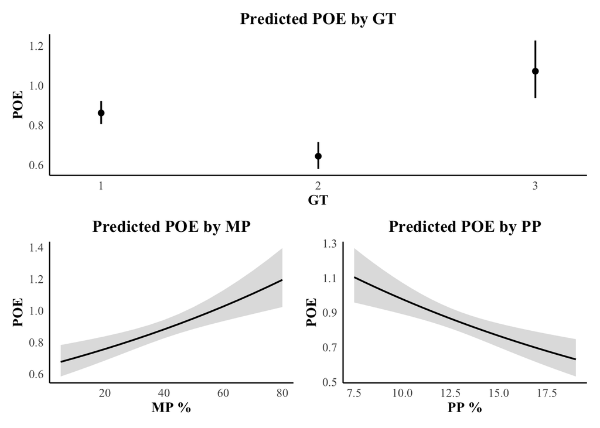

```r
library(ggeffects)
library(patchwork)
# Create individual ggpredict plots and assign them to variables
plot1 <- ggpredict(M2b1_a, "Trifecta") |> plot() + theme_apa() +
  labs(title = "Predicted POE by GT",
       x = "GT",
       y = "POE") #+
  #scale_x_discrete(labels = c("No", "Yes"))

plot2 <- ggpredict(M2b1_a, "Minority_percent") |> plot() + theme_apa() +
   labs(title = "Predicted POE by MP",
       x = "MP %",
       y = "POE") #+
  #scale_x_discrete(labels = c("No", "Yes"))

plot3 <- ggpredict(M2b1_a, "Poverty_percent") |> plot() + theme_apa() +
   labs(title = "Predicted POE by PP",
       x = "PP %",
       y = "POE")



# Create the combined plot
combined_plot3 <- plot1/(plot2 + plot3)

# Print the combined plot
print(combined_plot3)
```

```r
# Save the combined boxplot as a PNG file
ggsave("SES_POE.png", plot = last_plot(), width = 8, height = 4, units = "in")
```

#Negative eff

```r
M2b2 <- zeroinfl(Negative_eff ~ Trifecta +
                            Minority_percent +
                            Poverty_percent,
                 dist = "poisson",
                 data = p4)
summary(M2b2)
```

```
##
## Call:
## zeroinfl(formula = Negative_eff ~ Trifecta + Minority_percent + Poverty_percent,
##     data = p4, dist = "poisson")
##
## Pearson residuals:
##      Min       1Q   Median       3Q      Max
## -0.14086 -0.12569 -0.10847 -0.07973 22.58280
##
## Count model coefficients (poisson with log link):
##                  Estimate Std. Error z value Pr(>|z|)
## (Intercept)       0.43326    0.73735   0.588  0.55681
## Trifecta2        -0.29707    0.45242  -0.657  0.51142
## Trifecta3        -0.05551    0.43345  -0.128  0.89810
## Minority_percent  0.03994    0.01334   2.993  0.00276 **
## Poverty_percent  -0.18042    0.07516  -2.400  0.01638 *
##
## Zero-inflation model coefficients (binomial with logit link):
##                  Estimate Std. Error z value Pr(>|z|)
## (Intercept)       4.00627    0.75592   5.300 1.16e-07 ***
## Trifecta2        -1.14650    0.41482  -2.764  0.00571 **
## Trifecta3        -0.85596    0.43288  -1.977  0.04800 *
## Minority_percent  0.02915    0.01294   2.252  0.02431 *
## Poverty_percent  -0.07924    0.07594  -1.043  0.29675
## ---
## Signif. codes:  0 '***' 0.001 '**' 0.01 '*' 0.05 '.' 0.1 ' ' 1
##
## Number of iterations in BFGS optimization: 16
## Log-likelihood:  -802 on 10 Df
```

```r
M2b2_a <- zeroinfl(Negative_eff ~ Trifecta +
                            Minority_percent +
                            Poverty_percent,
                 dist = "negbin",
                 data = p4)
summary(M2b2_a)
```

```
##
## Call:
## zeroinfl(formula = Negative_eff ~ Trifecta + Minority_percent + Poverty_percent,
##     data = p4, dist = "negbin")
##
## Pearson residuals:
##      Min       1Q   Median       3Q      Max
## -0.14184 -0.11791 -0.10150 -0.08021 19.64643
##
## Count model coefficients (negbin with log link):
##                  Estimate Std. Error z value Pr(>|z|)
## (Intercept)      -2.87379    0.57210  -5.023 5.08e-07 ***
## Trifecta2         0.03771    0.38401   0.098 0.921777
## Trifecta3         0.43497    0.36452   1.193 0.232772
## Minority_percent  0.03839    0.01292   2.971 0.002971 **
## Poverty_percent  -0.19436    0.05799  -3.351 0.000804 ***
## Log(theta)       -3.47239    0.19099 -18.181  < 2e-16 ***
##
## Zero-inflation model coefficients (binomial with logit link):
##                  Estimate Std. Error z value Pr(>|z|)
## (Intercept)      -25.2406    16.3229  -1.546   0.1220
## Trifecta2        -23.9915    13.0828  -1.834   0.0667 .
## Trifecta3         -0.7603     2.4235  -0.314   0.7537
## Minority_percent   1.1737     0.6557   1.790   0.0735 .
## Poverty_percent   -2.1149     1.4951  -1.415   0.1572
## ---
## Signif. codes:  0 '***' 0.001 '**' 0.01 '*' 0.05 '.' 0.1 ' ' 1
##
## Theta = 0.031
## Number of iterations in BFGS optimization: 70
## Log-likelihood: -792.8 on 11 Df
```

```r
M2b2_b <- zeroinfl(Negative_eff ~ Trifecta +
                            Minority_percent +
                            Poverty_percent,
                 dist = "geometric",
                 data = p4)
summary(M2b2_b)
```

```
##
## Call:
## zeroinfl(formula = Negative_eff ~ Trifecta + Minority_percent + Poverty_percent,
##     data = p4, dist = "geometric")
##
## Pearson residuals:
##      Min       1Q   Median       3Q      Max
## -0.13839 -0.12209 -0.10201 -0.08041 21.59980
##
## Count model coefficients (geometric with log link):
##                  Estimate Std. Error z value Pr(>|z|)
## (Intercept)       0.61692    1.01896   0.605  0.54489
## Trifecta2        -0.60669    0.58224  -1.042  0.29741
## Trifecta3        -0.39603    0.56712  -0.698  0.48499
## Minority_percent  0.05836    0.01955   2.985  0.00283 **
## Poverty_percent  -0.28641    0.11360  -2.521  0.01169 *
##
## Zero-inflation model coefficients (binomial with logit link):
##                  Estimate Std. Error z value Pr(>|z|)
## (Intercept)       4.18006    1.08940   3.837 0.000125 ***
## Trifecta2        -1.46877    0.53464  -2.747 0.006010 **
## Trifecta3        -1.23687    0.60154  -2.056 0.039764 *
## Minority_percent  0.04846    0.02053   2.361 0.018242 *
## Poverty_percent  -0.19059    0.12699  -1.501 0.133404
## ---
## Signif. codes:  0 '***' 0.001 '**' 0.01 '*' 0.05 '.' 0.1 ' ' 1
##
## Number of iterations in BFGS optimization: 17
## Log-likelihood: -798.8 on 10 Df
```

```r
# Run the Vuong test to compare the models
vuong_test2 <- vuong(M2b2, M2b2_a)
```

```
## Vuong Non-Nested Hypothesis Test-Statistic:
## (test-statistic is asymptotically distributed N(0,1) under the
##  null that the models are indistinguishible)
## -------------------------------------------------------------
##               Vuong z-statistic             H_A  p-value
## Raw                   -2.001201 model2 > model1 0.022685
## AIC-corrected         -2.001201 model2 > model1 0.022685
## BIC-corrected         -2.001201 model2 > model1 0.022685
```

```r
vuong_test2_a <- vuong(M2b2_a, M2b2_b)
```

```
## Vuong Non-Nested Hypothesis Test-Statistic:
## (test-statistic is asymptotically distributed N(0,1) under the
##  null that the models are indistinguishible)
## -------------------------------------------------------------
##               Vuong z-statistic             H_A p-value
## Raw                    1.700275 model1 > model2 0.04454
## AIC-corrected          1.700275 model1 > model2 0.04454
## BIC-corrected          1.700275 model1 > model2 0.04454
```

```r
vuong_test2_b <- vuong(M2b2, M2b2_b)
```

```
## Vuong Non-Nested Hypothesis Test-Statistic:
## (test-statistic is asymptotically distributed N(0,1) under the
##  null that the models are indistinguishible)
## -------------------------------------------------------------
##               Vuong z-statistic             H_A p-value
## Raw                   -1.268795 model2 > model1 0.10226
## AIC-corrected         -1.268795 model2 > model1 0.10226
## BIC-corrected         -1.268795 model2 > model1 0.10226
```

```r
# View the results of the Vuong test
#summary(vuong_test2)
```

==> negbin

```r
model_parameters(M2b2_a)
```

```
## # Fixed Effects
##
## Parameter        | Log-Mean |   SE |         95% CI |     z |      p
## --------------------------------------------------------------------
## (Intercept)      |    -2.87 | 0.57 | [-4.00, -1.75] | -5.02 | < .001
## Trifecta [2]     |     0.04 | 0.38 | [-0.71,  0.79] |  0.10 | 0.922
## Trifecta [3]     |     0.43 | 0.36 | [-0.28,  1.15] |  1.19 | 0.233
## Minority percent |     0.04 | 0.01 | [ 0.01,  0.06] |  2.97 | 0.003
## Poverty percent  |    -0.19 | 0.06 | [-0.31, -0.08] | -3.35 | < .001
##
## # Zero-Inflation
##
## Parameter        | Log-Odds |    SE |         95% CI |     z |     p
## --------------------------------------------------------------------
## (Intercept)      |   -25.24 | 16.32 | [-57.23, 6.75] | -1.55 | 0.122
## Trifecta [2]     |   -23.99 | 13.08 | [-49.63, 1.65] | -1.83 | 0.067
## Trifecta [3]     |    -0.76 |  2.42 | [ -5.51, 3.99] | -0.31 | 0.754
## Minority percent |     1.17 |  0.66 | [ -0.11, 2.46] |  1.79 | 0.073
## Poverty percent  |    -2.11 |  1.50 | [ -5.05, 0.82] | -1.41 | 0.157
```

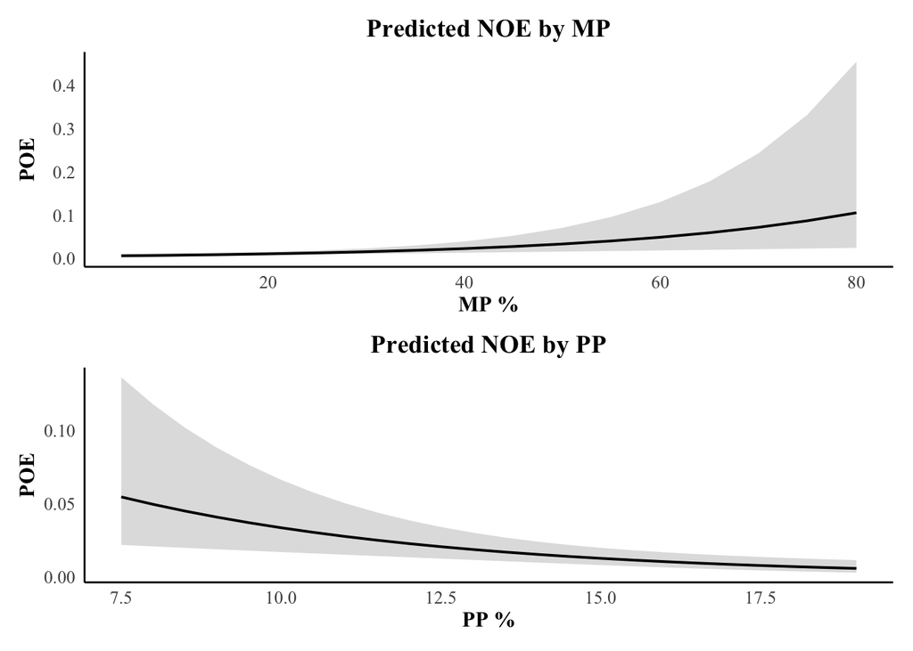

```r
library(ggeffects)
library(patchwork)
# Create individual ggpredict plots and assign them to variable

plot2 <- ggpredict(M2b2_a, "Minority_percent") |> plot() + theme_apa() +
   labs(title = "Predicted NOE by MP",
       x = "MP %",
       y = "POE") #+
  #scale_x_discrete(labels = c("No", "Yes"))

plot3 <- ggpredict(M2b2_a, "Poverty_percent") |> plot() + theme_apa() +
   labs(title = "Predicted NOE by PP",
       x = "PP %",
       y = "POE")

# Create the combined plot
combined_plot<- plot2/plot3

# Print the combined plot
print(combined_plot)
```

```r
# Save the combined boxplot as a PNG file
ggsave("SES_NOE.png", plot = last_plot(), width = 8, height = 4, units = "in")
```

#Collective eff

```r
M2b3 <- zeroinfl(Collective_eff ~ Trifecta +
                            Minority_percent +
                            Poverty_percent,
                 dist = 'poisson',
                 data = p4)
summary(M2b3)
```

```
##
## Call:
## zeroinfl(formula = Collective_eff ~ Trifecta + Minority_percent + Poverty_percent,
##     data = p4, dist = "poisson")
##
## Pearson residuals:
##     Min      1Q  Median      3Q     Max
## -0.8879 -0.5972 -0.4938  0.4980 16.8167
##
## Count model coefficients (poisson with log link):
##                    Estimate Std. Error z value Pr(>|z|)
## (Intercept)      -0.1907645  0.1539860  -1.239  0.21540
## Trifecta2        -0.1662426  0.0602330  -2.760  0.00578 **
## Trifecta3         0.3549406  0.0754309   4.706 2.53e-06 ***
## Minority_percent  0.0003351  0.0021703   0.154  0.87729
## Poverty_percent  -0.0040665  0.0137905  -0.295  0.76809
##
## Zero-inflation model coefficients (binomial with logit link):
##                   Estimate Std. Error z value Pr(>|z|)
## (Intercept)      -0.267937   0.352778  -0.760 0.447549
## Trifecta2         0.541765   0.157086   3.449 0.000563 ***
## Trifecta3         0.540259   0.155885   3.466 0.000529 ***
## Minority_percent -0.062416   0.005099 -12.240  < 2e-16 ***
## Poverty_percent   0.144477   0.030669   4.711 2.47e-06 ***
## ---
## Signif. codes:  0 '***' 0.001 '**' 0.01 '*' 0.05 '.' 0.1 ' ' 1
##
## Number of iterations in BFGS optimization: 21
## Log-likelihood: -8567 on 10 Df
```

```r
M2b3_1 <- zeroinfl(Collective_eff ~ Trifecta +
                            Minority_percent +
                            Poverty_percent,
                 dist = 'negbin',
                 data = p4)
summary(M2b3_1)
```

```
##
## Call:
## zeroinfl(formula = Collective_eff ~ Trifecta + Minority_percent + Poverty_percent,
##     data = p4, dist = "negbin")
##
## Pearson residuals:
##     Min      1Q  Median      3Q     Max
## -0.7439 -0.6133 -0.4869  0.5194 25.4118
##
## Count model coefficients (negbin with log link):
##                   Estimate Std. Error z value Pr(>|z|)
## (Intercept)      -0.700873   0.153042  -4.580 4.66e-06 ***
## Trifecta2        -0.298930   0.066628  -4.487 7.24e-06 ***
## Trifecta3         0.089059   0.065477   1.360   0.1738
## Minority_percent  0.005446   0.002418   2.252   0.0243 *
## Poverty_percent   0.006547   0.012505   0.524   0.6006
## Log(theta)        0.766207   0.120041   6.383 1.74e-10 ***
##
## Zero-inflation model coefficients (binomial with logit link):
##                   Estimate Std. Error z value Pr(>|z|)
## (Intercept)      -2.262001   0.661948  -3.417 0.000633 ***
## Trifecta2         0.420065   0.461782   0.910 0.363002
## Trifecta3        -0.678380   0.288377  -2.352 0.018653 *
## Minority_percent -0.100494   0.008511 -11.807  < 2e-16 ***
## Poverty_percent   0.328533   0.047879   6.862 6.81e-12 ***
## ---
## Signif. codes:  0 '***' 0.001 '**' 0.01 '*' 0.05 '.' 0.1 ' ' 1
##
## Theta = 2.1516
## Number of iterations in BFGS optimization: 39
## Log-likelihood: -8512 on 11 Df
```

```r
vuong_test2 <- vuong(M2b3, M2b3_1)
```

```
## Vuong Non-Nested Hypothesis Test-Statistic:
## (test-statistic is asymptotically distributed N(0,1) under the
##  null that the models are indistinguishible)
## -------------------------------------------------------------
##               Vuong z-statistic             H_A    p-value
## Raw                   -3.916956 model2 > model1 4.4837e-05
## AIC-corrected         -3.916956 model2 > model1 4.4837e-05
## BIC-corrected         -3.916956 model2 > model1 4.4837e-05
```

==> negbin

```r
model_parameters(M2b3_1)
```

```
## # Fixed Effects
##
## Parameter        | Log-Mean |       SE |         95% CI |     z |      p
## ------------------------------------------------------------------------
## (Intercept)      |    -0.70 |     0.15 | [-1.00, -0.40] | -4.58 | < .001
## Trifecta [2]     |    -0.30 |     0.07 | [-0.43, -0.17] | -4.49 | < .001
## Trifecta [3]     |     0.09 |     0.07 | [-0.04,  0.22] |  1.36 | 0.174
## Minority percent | 5.45e-03 | 2.42e-03 | [ 0.00,  0.01] |  2.25 | 0.024
## Poverty percent  | 6.55e-03 |     0.01 | [-0.02,  0.03] |  0.52 | 0.601
##
## # Zero-Inflation
##
## Parameter        | Log-Odds |       SE |         95% CI |      z |      p
## -------------------------------------------------------------------------
## (Intercept)      |    -2.26 |     0.66 | [-3.56, -0.96] |  -3.42 | < .001
## Trifecta [2]     |     0.42 |     0.46 | [-0.49,  1.33] |   0.91 | 0.363
## Trifecta [3]     |    -0.68 |     0.29 | [-1.24, -0.11] |  -2.35 | 0.019
## Minority percent |    -0.10 | 8.51e-03 | [-0.12, -0.08] | -11.81 | < .001
## Poverty percent  |     0.33 |     0.05 | [ 0.23,  0.42] |   6.86 | < .001
```

```r
# Create individual ggpredict plots and assign them to variables
plot1 <- ggpredict(M2b3, "Trifecta") |> plot() + theme_apa() +
  labs(title = "Predicted COE by GT",
       x = "GT",
       y = "COE")

plot2 <- ggpredict(M2b3, "Minority_percent") |> plot() + theme_apa() +
  labs(title = "Predicted COE by MP",
       x = "MP %",
       y = "COE")

combined_plot5 <- plot_grid(plot1,
                            plot2,
                            ncol = 1)
```

[output not shown]

[output cut: 70 more lines]

[output not shown]

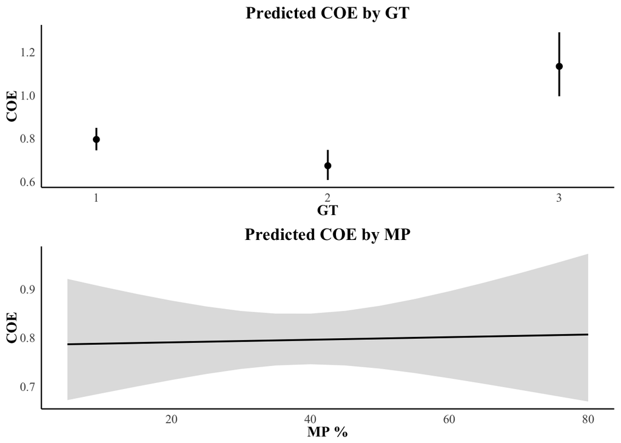

```r
# Print the combined plot
print(combined_plot5)
```

```r
# Save the combined boxplot as a PNG file
ggsave("SES_COE.png", plot = combined_plot5, width = 8, height = 4, units = "in")
```

#Individual Eff

```r
M2b4 <- zeroinfl(Individual_eff ~ Trifecta +
                            Minority_percent +
                            Poverty_percent,
                 dist = 'poisson',
                 data = p4)
summary(M2b4)
```

```
##
## Call:
## zeroinfl(formula = Individual_eff ~ Trifecta + Minority_percent + Poverty_percent,
##     data = p4, dist = "poisson")
##
## Pearson residuals:
##     Min      1Q  Median      3Q     Max
## -0.4052 -0.3841 -0.3539 -0.3162 16.3346
##
## Count model coefficients (poisson with log link):
##                   Estimate Std. Error z value Pr(>|z|)
## (Intercept)       0.574985   0.269523   2.133   0.0329 *
## Trifecta2        -0.260080   0.111252  -2.338   0.0194 *
## Trifecta3        -0.666795   0.152123  -4.383 1.17e-05 ***
## Minority_percent  0.018646   0.003312   5.629 1.81e-08 ***
## Poverty_percent  -0.130076   0.019735  -6.591 4.36e-11 ***
##
## Zero-inflation model coefficients (binomial with logit link):
##                  Estimate Std. Error z value Pr(>|z|)
## (Intercept)       1.81250    0.39763   4.558 5.16e-06 ***
## Trifecta2        -0.07456    0.15112  -0.493  0.62173
## Trifecta3        -0.73350    0.26896  -2.727  0.00639 **
## Minority_percent  0.02897    0.00503   5.759 8.48e-09 ***
## Poverty_percent  -0.16204    0.03408  -4.755 1.98e-06 ***
## ---
## Signif. codes:  0 '***' 0.001 '**' 0.01 '*' 0.05 '.' 0.1 ' ' 1
##
## Number of iterations in BFGS optimization: 18
## Log-likelihood: -4744 on 10 Df
```

```r
M2b4_a <- zeroinfl(Individual_eff ~ Trifecta +
                            Minority_percent +
                            Poverty_percent,
                 dist = 'geometric',
                 data = p4)
summary(M2b4_a)
```

```
##
## Call:
## zeroinfl(formula = Individual_eff ~ Trifecta + Minority_percent + Poverty_percent,
##     data = p4, dist = "geometric")
##
## Pearson residuals:
##     Min      1Q  Median      3Q     Max
## -0.3894 -0.3752 -0.3513 -0.3076 15.4001
##
## Count model coefficients (geometric with log link):
##                   Estimate Std. Error z value Pr(>|z|)
## (Intercept)      -0.212780   0.327339  -0.650  0.51567
## Trifecta2        -0.116236   0.135779  -0.856  0.39196
## Trifecta3        -0.615429   0.152699  -4.030 5.57e-05 ***
## Minority_percent  0.011459   0.003945   2.904  0.00368 **
## Poverty_percent  -0.095650   0.020641  -4.634 3.59e-06 ***
##
## Zero-inflation model coefficients (binomial with logit link):
##                   Estimate Std. Error z value Pr(>|z|)
## (Intercept)       0.942157   0.681357   1.383 0.166737
## Trifecta2         0.122291   0.238508   0.513 0.608136
## Trifecta3        -1.249110   0.567686  -2.200 0.027782 *
## Minority_percent  0.031849   0.007586   4.199 2.69e-05 ***
## Poverty_percent  -0.187629   0.050019  -3.751 0.000176 ***
## ---
## Signif. codes:  0 '***' 0.001 '**' 0.01 '*' 0.05 '.' 0.1 ' ' 1
##
## Number of iterations in BFGS optimization: 24
## Log-likelihood: -4702 on 10 Df
```

```r
# Run the Vuong test to compare the models
vuong_test4 <- vuong(M2b4, M2b4_a)
```

```
## Vuong Non-Nested Hypothesis Test-Statistic:
## (test-statistic is asymptotically distributed N(0,1) under the
##  null that the models are indistinguishible)
## -------------------------------------------------------------
##               Vuong z-statistic             H_A    p-value
## Raw                   -4.064049 model2 > model1 2.4114e-05
## AIC-corrected         -4.064049 model2 > model1 2.4114e-05
## BIC-corrected         -4.064049 model2 > model1 2.4114e-05
```

==> geometric

```r
model_parameters(M2b4_a)
```

```
## # Fixed Effects
##
## Parameter        | Log-Mean |       SE |         95% CI |     z |      p
## ------------------------------------------------------------------------
## (Intercept)      |    -0.21 |     0.33 | [-0.85,  0.43] | -0.65 | 0.516
## Trifecta [2]     |    -0.12 |     0.14 | [-0.38,  0.15] | -0.86 | 0.392
## Trifecta [3]     |    -0.62 |     0.15 | [-0.91, -0.32] | -4.03 | < .001
## Minority percent |     0.01 | 3.95e-03 | [ 0.00,  0.02] |  2.90 | 0.004
## Poverty percent  |    -0.10 |     0.02 | [-0.14, -0.06] | -4.63 | < .001
##
## # Zero-Inflation
##
## Parameter        | Log-Odds |       SE |         95% CI |     z |      p
## ------------------------------------------------------------------------
## (Intercept)      |     0.94 |     0.68 | [-0.39,  2.28] |  1.38 | 0.167
## Trifecta [2]     |     0.12 |     0.24 | [-0.35,  0.59] |  0.51 | 0.608
## Trifecta [3]     |    -1.25 |     0.57 | [-2.36, -0.14] | -2.20 | 0.028
## Minority percent |     0.03 | 7.59e-03 | [ 0.02,  0.05] |  4.20 | < .001
## Poverty percent  |    -0.19 |     0.05 | [-0.29, -0.09] | -3.75 | < .001
```

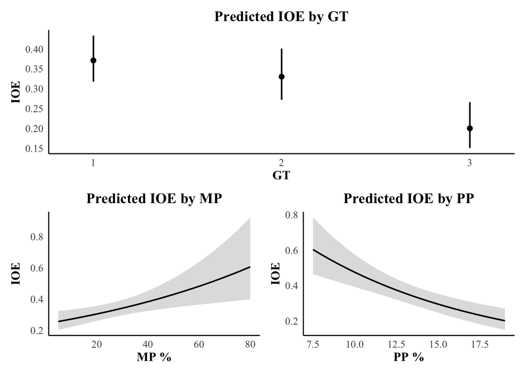

```r
# Create individual ggpredict plots and assign them to variables
plot1 <- ggpredict(M2b4_a, "Trifecta") |> plot() + theme_apa() +
  labs(title = "Predicted IOE by GT",
       x = "GT",
       y = "IOE")
plot2 <- ggpredict(M2b4_a, "Minority_percent") |> plot() + theme_apa() +
  labs(title = "Predicted IOE by MP",
       x = "MP %",
       y = "IOE")

plot3 <- ggpredict(M2b4_a, "Poverty_percent") |> plot() + theme_apa() +
  labs(title = "Predicted IOE by PP",
       x = "PP %",
       y = "IOE")

# Create the combined plot
combined_plot6 <- plot1/(plot2 + plot3)

# Print the combined plot
print(combined_plot6)
```

```r
# Save the combined boxplot as a PNG file
ggsave("SES_IOE.png", plot = combined_plot6, width = 8, height = 4, units = "in")
```

```r
library(car)
Anova(M2b1, type = 3)
```

```
## Analysis of Deviance Table (Type III tests)
##
## Response: Positive_eff
##                  Df  Chisq Pr(>Chisq)
## Trifecta          2 53.436  2.492e-12 ***
## Minority_percent  1  6.227    0.01258 *
## Poverty_percent   1 18.812  1.443e-05 ***
## ---
## Signif. codes:  0 '***' 0.001 '**' 0.01 '*' 0.05 '.' 0.1 ' ' 1
```

```r
Anova(M2b2, type = 3)
```

```
## Analysis of Deviance Table (Type III tests)
##
## Response: Negative_eff
##                  Df  Chisq Pr(>Chisq)
## Trifecta          2 0.6425   0.725229
## Minority_percent  1 8.9580   0.002763 **
## Poverty_percent   1 5.7618   0.016378 *
## ---
## Signif. codes:  0 '***' 0.001 '**' 0.01 '*' 0.05 '.' 0.1 ' ' 1
```

```r
Anova(M2b3, type = 3)
```

```
## Analysis of Deviance Table (Type III tests)
##
## Response: Collective_eff
##                  Df   Chisq Pr(>Chisq)
## Trifecta          2 31.9643  1.146e-07 ***
## Minority_percent  1  0.0238     0.8773
## Poverty_percent   1  0.0870     0.7681
## ---
## Signif. codes:  0 '***' 0.001 '**' 0.01 '*' 0.05 '.' 0.1 ' ' 1
```

```r
Anova(M2b4, type = 3)
```

```
## Analysis of Deviance Table (Type III tests)
##
## Response: Individual_eff
##                  Df  Chisq Pr(>Chisq)
## Trifecta          2 21.120  2.594e-05 ***
## Minority_percent  1 31.688  1.811e-08 ***
## Poverty_percent   1 43.443  4.364e-11 ***
## ---
## Signif. codes:  0 '***' 0.001 '**' 0.01 '*' 0.05 '.' 0.1 ' ' 1
```

# Question 3: How CTA is predicted by risk factors and socio-economic factors

#LOGISTIC

Convert pre_Action to a binary variable

```r
library(tidyverse)
p2b <- p2 %>%
  mutate(Pre_Action1 = case_when(
    Pre_Action == '0' ~ 0,
    Pre_Action %in% c('1', '10', '11', '12', '13', '14', '17') ~ 1,
    TRUE ~ NA_real_
  ))
p2b
```

```
## # A tibble: 9,445 × 33
##    Post_oldid Real_ID date   COVID_Post Risk_Factor Social_Disparities Debunk_MI
##    <chr>        <dbl> <chr>       <dbl>       <dbl>              <dbl>     <dbl>
##  1 1             2069 9/22/…          1           1                  1         1
##  2 2             2070 8/27/…          1           1                  1         1
##  3 3             2071 12/29…          1           1                  1         1
##  4 4             2072 9/29/…          1           1                  1         1
##  5 5             2073 10/6/…          1           1                  1         1
##  6 6             2074 12/31…          1           1                  1         1
##  7 7              403 4/2/20          1           1                  1         1
##  8 8             5425 12/1/…          1           1                  1         1
##  9 9             5842 12/20…          1           1                  1         1
## 10 10            2075 3/5/20          1           1                  1         1
## # ℹ 9,435 more rows
## # ℹ 26 more variables: Uncertainty_Reduction <dbl>, Testing <dbl>,
## #   Vaccine <dbl>, Mental_8_YesNo <dbl>, Emotion_9_Number <dbl>,
## #   Praise_10_Number <dbl>, Pop_11_Number <dbl>, Language_12_Number <dbl>,
## #   Pre_Action <dbl>, Positive_eff <dbl>, Negative_eff <dbl>,
## #   Individual_eff <dbl>, Collective_eff <dbl>, State_recode <dbl>,
## #   Gov_poli <dbl>, Trifecta <dbl>, White_percent <dbl>, …
```

#risk factors

```r
model1 <- glm(Pre_Action1 ~ Risk_Factor + Social_Disparities +
                Debunk_MI + Uncertainty_Reduction,
               data = p2b, family = binomial)
summary(model1)
```

```
##
## Call:
## glm(formula = Pre_Action1 ~ Risk_Factor + Social_Disparities +
##     Debunk_MI + Uncertainty_Reduction, family = binomial, data = p2b)
##
## Coefficients:
##                       Estimate Std. Error z value Pr(>|z|)
## (Intercept)            -3.2337     0.5373  -6.019 1.76e-09 ***
## Risk_Factor             1.4964     0.2545   5.879 4.12e-09 ***
## Social_Disparities      0.5255     0.3133   1.677   0.0935 .
## Debunk_MI              -0.2019     0.1827  -1.105   0.2692
## Uncertainty_Reduction   1.5197     0.1375  11.049  < 2e-16 ***
## ---
## Signif. codes:  0 '***' 0.001 '**' 0.01 '*' 0.05 '.' 0.1 ' ' 1
##
## (Dispersion parameter for binomial family taken to be 1)
##
##     Null deviance: 5036.2  on 5531  degrees of freedom
## Residual deviance: 4874.4  on 5527  degrees of freedom
##   (3913 observations deleted due to missingness)
## AIC: 4884.4
##
## Number of Fisher Scoring iterations: 5
```

```r
library(easystats)
library(ggeffects)
model_parameters(model1)
```

```
## Parameter             | Log-Odds |   SE |         95% CI |     z |      p
## -------------------------------------------------------------------------
## (Intercept)           |    -3.23 | 0.54 | [-4.32, -2.21] | -6.02 | < .001
## Risk Factor           |     1.50 | 0.25 | [ 1.03,  2.03] |  5.88 | < .001
## Social Disparities    |     0.53 | 0.31 | [-0.05,  1.19] |  1.68 | 0.093
## Debunk MI             |    -0.20 | 0.18 | [-0.55,  0.17] | -1.10 | 0.269
## Uncertainty Reduction |     1.52 | 0.14 | [ 1.25,  1.79] | 11.05 | < .001
```

```
##
## Uncertainty intervals (profile-likelihood) and p-values (two-tailed)
##   computed using a Wald z-distribution approximation.
```

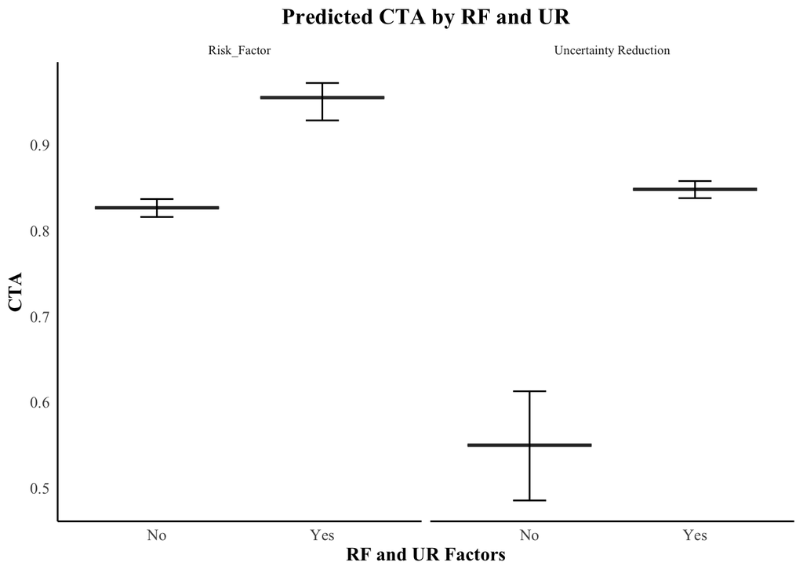

```r
# Create ggeffects objects for Risk_Factor and Social_Disparities
ge_social <- ggpredict(model1, terms = "Uncertainty_Reduction")
ge_debunk <- ggpredict(model1, terms = "Risk_Factor")

# Create data frames for both boxplots
boxplot_data_social <- data.frame(
  Group = "Uncertainty Reduction",  # Add a Group column to identify the data source
  Uncertainty_Reduction = c(0, 1),
  Predicted = ge_social$predicted,
  CI_lower = ge_social$conf.low,
  CI_upper = ge_social$conf.high
)

boxplot_data_risk <- data.frame(
  Group = "Risk_Factor",  # Add a Group column to identify the data source
  Uncertainty_Reduction = c(0, 1),  # Ensure that the column name matches the previous data frame
  Predicted = ge_debunk$predicted,
  CI_lower = ge_debunk$conf.low,
  CI_upper = ge_debunk$conf.high
)


# Combine the data frames
combined_dataz <- rbind(boxplot_data_social, boxplot_data_risk)

# Create a boxplot with facets
ggplot(combined_dataz, aes(x = as.factor(Uncertainty_Reduction ), y = Predicted)) +
  geom_boxplot() +
  geom_errorbar(aes(ymin = CI_lower, ymax = CI_upper), width = 0.2, position = position_dodge(0.75)) +
  labs(title = "Predicted CTA by RF and UR",
       x = "RF and UR Factors",
       y = "CTA") +
  scale_x_discrete(labels = c("No", "Yes")) +
  facet_grid(. ~ Group) +  # Facet by Group (Risk Factor and Social Disparities)
  theme_apa()
```

```r
# Save the combined boxplot as a PNG file
ggsave("CTA_risk.png", plot = last_plot(), width = 8, height = 4, units = "in")
```

#socio

```r
model2 <- glm(Pre_Action1 ~ Trifecta + Minority_percent +
                Poverty_percent , data = p2b, family = binomial)
summary(model2)
```

```
##
## Call:
## glm(formula = Pre_Action1 ~ Trifecta + Minority_percent + Poverty_percent,
##     family = binomial, data = p2b)
##
## Coefficients:
##                   Estimate Std. Error z value Pr(>|z|)
## (Intercept)       0.556205   0.206107   2.699  0.00696 **
## Trifecta         -0.044735   0.053386  -0.838  0.40206
## Minority_percent  0.003697   0.002334   1.584  0.11320
## Poverty_percent   0.078022   0.014902   5.236 1.64e-07 ***
## ---
## Signif. codes:  0 '***' 0.001 '**' 0.01 '*' 0.05 '.' 0.1 ' ' 1
##
## (Dispersion parameter for binomial family taken to be 1)
##
##     Null deviance: 5036.2  on 5531  degrees of freedom
## Residual deviance: 4994.1  on 5528  degrees of freedom
##   (3913 observations deleted due to missingness)
## AIC: 5002.1
##
## Number of Fisher Scoring iterations: 4
```

```r
library(easystats)
library(ggeffects)
model_parameters(model2)
```

```
## Parameter        | Log-Odds |       SE |        95% CI |     z |      p
## -----------------------------------------------------------------------
## (Intercept)      |     0.56 |     0.21 | [ 0.15, 0.96] |  2.70 | 0.007
## Trifecta         |    -0.04 |     0.05 | [-0.15, 0.06] | -0.84 | 0.402
## Minority percent | 3.70e-03 | 2.33e-03 | [ 0.00, 0.01] |  1.58 | 0.113
## Poverty percent  |     0.08 |     0.01 | [ 0.05, 0.11] |  5.24 | < .001
```

```
##
## Uncertainty intervals (profile-likelihood) and p-values (two-tailed)
##   computed using a Wald z-distribution approximation.
```

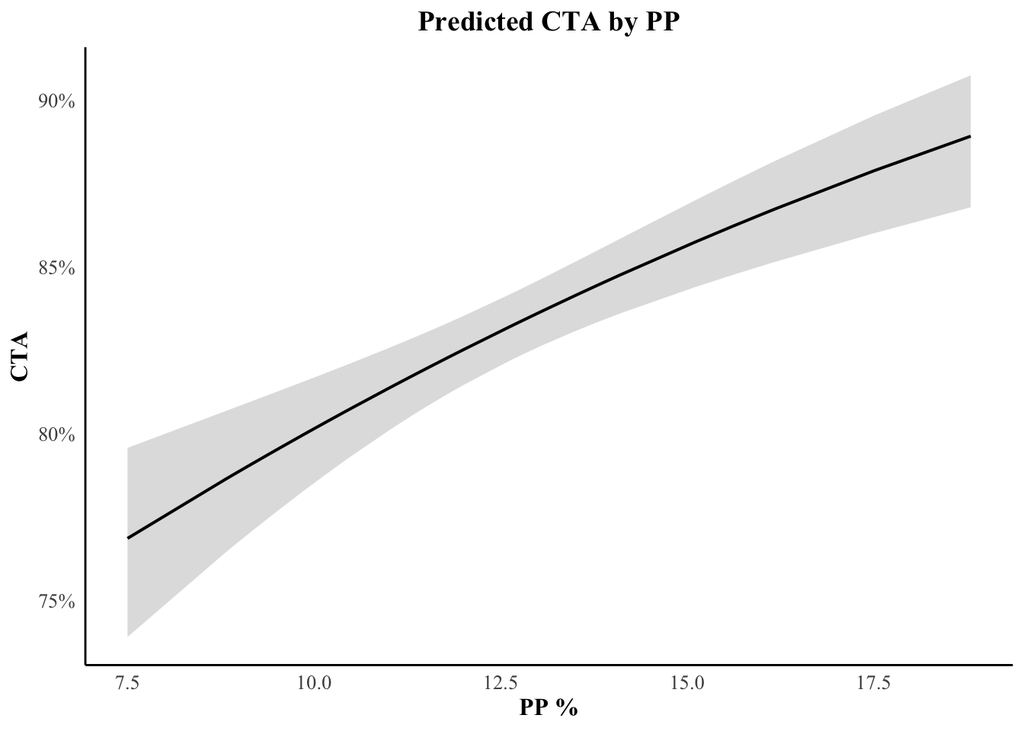

```r
plotb1 <- ggpredict(model2, "Poverty_percent[all]") |> plot() + theme_apa() +
  labs(title = "Predicted CTA by PP",
       x = "PP %",
       y = "CTA")
plotb1
```

```r
#save
ggsave("CTA_SES.png", plot = plotb1, width = 8, height = 4, units = "in")
```

==========END HERE===================END HERE===================END HERE========